# Práctica Final. Reglas de Asociación y Detección de Anomalías

Javier Galván Fraile

18/04/2020

**Resolver los siguientes problemas usando R. Aseguraros de comentar detalladamente el script para facilitar su implementación.**

# Exercise 1.

**Brief outline**. A bakery chain has a menu of about 40 pastry items and 10 coffee drinks. It has a number of locations in West Coast states (California, Oregon, Arizona, Nevada). The database stores information about the food/drinks offered for sale, locations, employees at each location and individual sales (receipts) at those locations. The document bakerygoods.txt offers a description of the goods. There are four canonical sets of data available for this dataset: a) 1,000 Receipts; b) 5,000 Receipts; c) 20,000 Receipts; d) 75,000 Receipts.

1. The XXXX-out1.csv file format is: receipt number followed by item numbers that are on that receipt (sparse vector representation).
2. The XXXX-out2.csv file format is: receipt number followed by 0’s and 1’s indicating if an item was on a given receipt (full binary vector representation).
3. The XXXXi.csv file format is: receipt number followed by item number and quantity (CSV version of the Items tables).

Using the data sets provided, find frequent itemsets, generate association rules and interpret the results. Present a visualization of the rules. Find redundant rules and interpret your findings. Study negative association rules and explain them.

## Solution

First of all, we load the required libraries to perform the association mining techniques.

```r
library(arules)
library(arulesViz)
```

In this particular problem we have a document called *bakerygoods.txt* which offers us a description of the goods that are sold at the different stores. Let us take a look at how this information is provided:

```r
goods.dat = read.table("bakerygoods.txt",
                 header = TRUE,
                 sep = "\t",
                 stringsAsFactors = TRUE)
goods.dat
```

```
##    id        name         type price category
## 1   0  Chocolate         Cake   8.95     Food
## 2   1      Lemon         Cake   8.95     Food
## 3   2     Casino         Cake  15.95     Food
## 4   3      Opera         Cake  15.95     Food
## 5   4 Strawberry         Cake  11.95     Food
## 6   5    Truffle         Cake  15.95     Food
## 7   6  Chocolate       Eclair   3.25     Food
## 8   7     Coffee       Eclair   3.50     Food
## 9   8    Vanilla       Eclair   3.25     Food
## 10  9   Napoleon         Cake  13.49     Food
## 11 10     Almond         Tart   3.75     Food
## 12 11      Apple          Pie   5.25     Food
## 13 12      Apple         Tart   3.25     Food
## 14 13    Apricot         Tart   3.25     Food
```

[output cut: 36 more lines]

We observe that the different goods present a wide range of prices, from 0.79 of the “Lemon Cookie” to 15.95 of the “Truffle Cake”, “Casino Cake” and “Opera Cake”. We are also provided with 3 different formats of the receipts and 4 sets of data: a) 1,000 Receipts; b) 5,000 Receipts; c) 20,000 Receipts; d) 75,000 Receipts. In our analysis of the problem we are going to use the *XXXXi.csv* file format as it provides us the quantity of items sold in every transaction, but either of the other two could have been considered. We are also going to perform a search of the most interesting association rules in each of the 4 data sets.

### a) 1000 receipts

#### Exploring the data set

In the first place, we load the data set and take a look on how the data is presented. For thar purpose we define a function which reads a csv file, uses the *goods.dat* table to change the item ID for the items name and creates a transaction object

```r
transactions.object <- function(csv.name){
dbi <- read.table(csv.name,
                header = FALSE,
                sep = ",",
                col.names=c("TID", "Quantity", "Item"),
                stringsAsFactors = FALSE)

items.name <- paste0(goods.dat$name[dbi$Item+1], goods.dat$type[dbi$Item+1]) #we create the new items name
datos_split <- split(x = items.name, f = dbi$TID) #create a list with items name and the transaction ID
transactions.obj <- as(datos_split, Class = "transactions")

return_list <- list("dbi"=dbi, "transactions.obj"=transactions.obj)
return(return_list)
}
```

```r
dataset = transactions.object("1000/1000i.csv")
dbi <- dataset$dbi
transactions.obj <- dataset$transactions.obj
head(dbi)
```

```
##   TID Quantity Item
## 1   1        3    7
## 2   1        4   15
## 3   1        2   49
## 4   1        5   44
## 5   2        1    1
## 6   2        2   19
```

We observe that each row presents, for a given transaction (TID), the quantity (Quantity) of a given item (Item) sold, being the item labelled with its ID which can be checked at the *goods.dat* table. Let’s check now the transactions object:

```r
inspect(transactions.obj[1:4,])
```

```
##     items              transactionID
## [1] {Blackberry Tart ,
##      Bottled Water ,
##      Coffee Eclair ,
##      Single Espresso }             1
## [2] {Lemon Cake ,
##      Lemon Tart }                  2
## [3] {Lemon Cake ,
##      Lemon Tart }                  3
## [4] {Apricot Danish ,
##      Blackberry Tart ,
##      Bottled Water ,
##      Cherry Tart ,
##      Opera Cake ,
##      Strawberry Cake }             4
```

In the first row we observe that “Blackberry Tart”, “Bottled Water”, “Coffee Eclair” and “Single Espresso” were bought together in the first transaction.

We can also see a summary of the transaction object which present some basic statistics of the data set.

```r
summary(transactions.obj)
```

```
## transactions as itemMatrix in sparse format with
##  1000 rows (elements/itemsets/transactions) and
##  50 columns (items) and a density of 0.07076
##
## most frequent items:
## Gongolais Cookie      Truffle Cake      Tuile Cookie        Berry Tart
##               108               103               102                95
##       Hot Coffee            (Other)
##                94              3036
##
## element (itemset/transaction) length distribution:
## sizes
##   1   2   3   4   5   6   7   8
##  60 162 338 216 132  44  32  16
##
##    Min. 1st Qu.  Median    Mean 3rd Qu.    Max.
##   1.000   3.000   3.000   3.538   4.000   8.000
##
## includes extended item information - examples:
##              labels
## 1 Almond Bear Claw
## 2 Almond Croissant
## 3      Almond Tart
##
## includes extended transaction information - examples:
##   transactionID
## 1             1
## 2             2
## 3             3
```

In order to get a little bit more of insight about or data set we can represent in a histogram the 20 most frequent items.

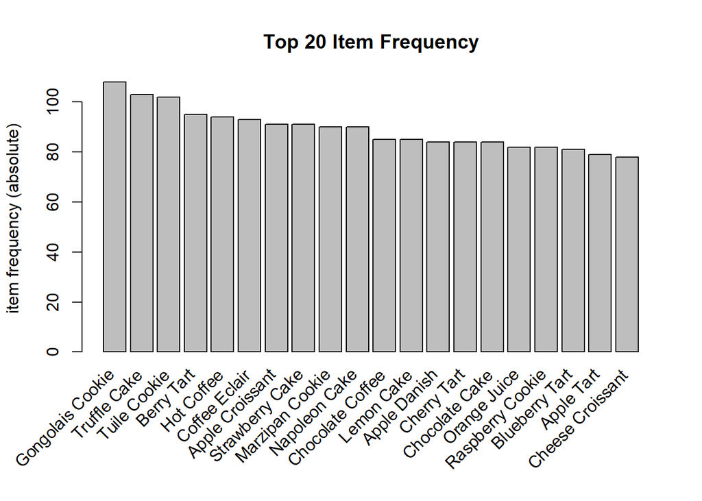

```r
itemFrequencyPlot(transactions.obj, topN=20, type="absolute", main="Top 20 Item Frequency")
```

From this representation we observe that there is not a great unbalance in the number of sales between the different items.

#### Most frequent itemsets

As it was stated in the beginning of the solution, our task is to look for rules in the data set. This means that we are looking relations amongst the different items of the form:

$$A \to B$$

which means that items in $B$ were likely to be purchased along with items in $A$. For the purpose of measuring the relative strength of the rules we are using three different quantities:

- **Support**: fraction of transactions that contain an itemset.
  $$s(A \rightarrow B)=\frac{\sigma(A, B)}{|T|}=P(A \cup B)$$
- **Confidence**: fraction of transactions containing $A$ that also contain $B$.
  $$c(A \rightarrow B)=\frac{s(A \rightarrow B)}{s(A)}=\frac{P(A \cup B)}{P(A)}$$
- **Lift**: measure of the probability of $A$ and $B$ occurring together with respect to the probability of $A$ and $B$ ocurring at random.
  $$\operatorname{lift}(A \rightarrow B)=\frac{c(A \rightarrow B)}{s(B)}=\frac{P(A \cup B)}{P(A) \cdot P(B)}$$

So our task is now to look for frequent itemsets using the “eclat()” function with a mininum support of 0.02 .

```r
frequentItems <- eclat(transactions.obj, parameter = list(support = 0.02, tidLists = TRUE))
```

```r
##Show the Frequent itemsets and respectives supports
inspect(frequentItems)
```

```
##       items                  support count
## [1]   {Chocolate Tart ,
##        Vanilla Frappuccino }   0.026    26
## [2]   {Blackberry Tart ,
##        Coffee Eclair ,
##        Single Espresso }       0.023    23
## [3]   {Coffee Eclair ,
##        Single Espresso }       0.024    24
## [4]   {Blackberry Tart ,
##        Single Espresso }       0.024    24
## [5]   {Blackberry Tart ,
##        Coffee Eclair }         0.031    31
## [6]   {Lemon Cookie ,
##        Lemon Lemonade ,
##        Raspberry Cookie ,
##        Raspberry Lemonade }    0.028    28
## [7]   {Lemon Cookie ,
##        Lemon Lemonade ,
##        Raspberry Cookie }      0.028    28
## [8]   {Lemon Cookie ,
##        Lemon Lemonade ,
##        Raspberry Lemonade }    0.028    28
## [9]   {Lemon Lemonade ,
##        Raspberry Cookie ,
##        Raspberry Lemonade }    0.028    28
## [10]  {Lemon Lemonade ,
##        Raspberry Cookie }      0.031    31
## [11]  {Lemon Lemonade ,
##        Raspberry Lemonade }    0.029    29
## [12]  {Lemon Cookie ,
##        Lemon Lemonade }        0.031    31
## [13]  {Green Tea ,
##        Lemon Lemonade }        0.021    21
## [14]  {Green Tea ,
##        Raspberry Cookie }      0.020    20
## [15]  {Green Tea ,
##        Raspberry Lemonade }    0.023    23
## [16]  {Green Tea ,
##        Lemon Cookie }          0.020    20
## [17]  {Almond Twist ,
```

[output cut: 138 more lines]

```
## [96]  {Walnut Cookie }         0.061    61
## [97]  {Blueberry Danish }      0.055    55
## [98]  {Single Espresso }       0.059    59
## [99]  {Apricot Tart }          0.056    56
## [100] {Vanilla Meringue }      0.047    47
## [101] {Ganache Cookie }        0.044    44
## [102] {Chocolate Tart }        0.051    51
## [103] {Almond Croissant }      0.049    49
## [104] {Almond Tart }           0.041    41
## [105] {Chocolate Meringue }    0.038    38
## [106] {Pecan Tart }            0.040    40
## [107] {Chocolate Croissant }   0.042    42
## [108] {Vanilla Eclair }        0.037    37
## [109] {Chocolate Eclair }      0.034    34
## [110] {Almond Bear Claw }      0.026    26
```

Let’s summarize all these frequent itemsets.

```r
summary(frequentItems)
```

```
## set of 110 itemsets
##
## most frequent items:
##    Coffee Eclair        Hot Coffee      Lemon Cookie    Lemon Lemonade
##                11                11                 9                 9
## Raspberry Cookie            (Other)
##                 9               143
##
## element (itemset/transaction) length distribution:sizes
##  1  2  3  4
## 50 41 16  3
##
##    Min. 1st Qu.  Median    Mean 3rd Qu.    Max.
##   1.000   1.000   2.000   1.745   2.000   4.000
##
## summary of quality measures:
##     support            count
##  Min.   :0.02000   Min.   : 20.00
##  1st Qu.:0.03100   1st Qu.: 31.00
##  Median :0.04000   Median : 40.00
##  Mean   :0.04999   Mean   : 49.99
##  3rd Qu.:0.07275   3rd Qu.: 72.75
##  Max.   :0.10800   Max.   :108.00
##
## includes transaction ID lists: TRUE
##
## mining info:
##              data ntransactions support
##  transactions.obj          1000    0.02
```

#### Association Rules using APRIORI

We aim now to find rules using the APRIORI algorithm. For that purpose we require the “apriori()” function of the *arules* library. We are going to look for rules with a minimum support of 0.02 and a minimum confidence of 0.8. It is important to notice that for this function we must set the minimum lenght of the rules to be 2, otherwise we would have rules with only 1 consequent and no antecendent. An important detail of the “apriori()” function is that it only creates rules with one item in the consequent. One may think that this is an issue, but that is no longer the case if we consider the two following properties.

> Moving items from the antecedent to the consequent never changes support.

> Moving items from the antecedent to the consequent never increases confidence.

Therefore, it guarantees us that we are obtaining the stronger rules of them all.

```r
#We require minlen 2 to avoid having rules with only 1 consequent and 0 antecedent
rules.ap <- apriori(transactions.obj, parameter = list(supp = 0.02, conf = 0.8, minlen=2))
```

```
## Apriori
##
## Parameter specification:
##  confidence minval smax arem  aval originalSupport maxtime support minlen
##         0.8    0.1    1 none FALSE            TRUE       5    0.02      2
##  maxlen target   ext
##      10  rules FALSE
##
## Algorithmic control:
##  filter tree heap memopt load sort verbose
##     0.1 TRUE TRUE  FALSE TRUE    2    TRUE
##
## Absolute minimum support count: 20
##
## set item appearances ...[0 item(s)] done [0.00s].
## set transactions ...[50 item(s), 1000 transaction(s)] done [0.00s].
## sorting and recoding items ... [50 item(s)] done [0.00s].
## creating transaction tree ... done [0.00s].
## checking subsets of size 1 2 3 4 done [0.00s].
## writing ... [54 rule(s)] done [0.00s].
## creating S4 object  ... done [0.00s].
```

We have obtained 54 rules, however some of them provide no extra information related to others. These are called **redudant rules** and we can find them automatically.

```r
inspect(rules.ap[is.redundant(rules.ap)])
```

```
##     lhs                      rhs               support confidence     lift count
## [1] {Lemon Lemonade ,
##      Raspberry Cookie ,
##      Raspberry Lemonade } => {Lemon Cookie }     0.028  1.0000000 15.15152    28
## [2] {Lemon Cookie ,
##      Raspberry Cookie ,
##      Raspberry Lemonade } => {Lemon Lemonade }   0.028  0.9655172 14.62905    28
```

Therefore, we are going to prune those redudant rules from our list of positive rules, so we get 52 rules.

```r
#Remove redundant rules
rules.ap <- rules.ap[!is.redundant(rules.ap)]
```

Let’s get now some statistical information on the rules.

```r
summary(rules.ap)
```

```
## set of 52 rules
##
## rule length distribution (lhs + rhs):sizes
##  3  4
## 43  9
##
##    Min. 1st Qu.  Median    Mean 3rd Qu.    Max.
##   3.000   3.000   3.000   3.173   3.000   4.000
##
## summary of quality measures:
##     support          confidence          lift            count
##  Min.   :0.02300   Min.   :0.8000   Min.   : 8.511   Min.   :23.00
##  1st Qu.:0.02400   1st Qu.:0.8972   1st Qu.:10.745   1st Qu.:24.00
##  Median :0.02800   Median :0.9394   Median :11.898   Median :28.00
##  Mean   :0.02948   Mean   :0.9267   Mean   :11.925   Mean   :29.48
##  3rd Qu.:0.03100   3rd Qu.:0.9709   3rd Qu.:12.924   3rd Qu.:31.00
##  Max.   :0.04000   Max.   :1.0000   Max.   :15.385   Max.   :40.00
##
## mining info:
##              data ntransactions support confidence
##  transactions.obj          1000    0.02        0.8
```

We observe that all the rules present both large values of confidence, with a mean of 0.9267, and lift, with a mean of 11.925 . Also, we do not have rules with more than 4 items, being 3.173 items the average.

So, let’s now classify the rules by lift:

```r
#High lift rules
rules.lift <- sort (rules.ap, by="lift", decreasing=TRUE)
inspect(head(rules.lift)) # show the support, lift and confidence for higher lift rules
```

```
##     lhs                      rhs               support confidence     lift count
## [1] {Apple Pie ,
##      Coffee Eclair ,
##      Hot Coffee }         => {Almond Twist }     0.024  1.0000000 15.38462    24
## [2] {Raspberry Cookie ,
##      Raspberry Lemonade } => {Lemon Cookie }     0.029  1.0000000 15.15152    29
## [3] {Almond Twist ,
##      Coffee Eclair ,
##      Hot Coffee }         => {Apple Pie }        0.024  1.0000000 14.70588    24
## [4] {Lemon Lemonade ,
##      Raspberry Lemonade } => {Lemon Cookie }     0.028  0.9655172 14.62905    28
## [5] {Raspberry Cookie ,
##      Raspberry Lemonade } => {Lemon Lemonade }   0.028  0.9655172 14.62905    28
## [6] {Coffee Eclair ,
##      Hot Coffee }         => {Almond Twist }     0.024  0.9230769 14.20118    24
```

Then, let’s classify the rules by confidence:

```r
#High confidence rules
rules.confidence <- sort (rules.ap, by="confidence", decreasing=TRUE)
inspect(head(rules.confidence)) # show the support, lift and confidence for high confidence rules
```

```
##     lhs                      rhs                   support confidence     lift count
## [1] {Apricot Croissant ,
##      Hot Coffee }         => {Blueberry Tart }       0.032          1 12.34568    32
## [2] {Raspberry Cookie ,
##      Raspberry Lemonade } => {Lemon Cookie }         0.029          1 15.15152    29
## [3] {Lemon Cookie ,
##      Lemon Lemonade ,
##      Raspberry Lemonade } => {Raspberry Cookie }     0.028          1 12.19512    28
## [4] {Lemon Cookie ,
##      Lemon Lemonade ,
##      Raspberry Cookie }   => {Raspberry Lemonade }   0.028          1 13.88889    28
## [5] {Almond Twist ,
##      Apple Pie ,
##      Hot Coffee }         => {Coffee Eclair }        0.024          1 10.75269    24
## [6] {Apple Pie ,
##      Coffee Eclair ,
##      Hot Coffee }         => {Almond Twist }         0.024          1 15.38462    24
```

The rules with a confidence of 1 mean that, whenever the LHS item was purchased, the RHS item was always purchased. We notice that lift and confidence give as more important rules those which are quite infrequent. Consequently, we will also classify the rules according to support:

```r
#High support rules
rules.support <- sort (rules.ap, by="support", decreasing=TRUE)

inspect(head(rules.support)) # show the support, lift and confidence for high support rules
```

```
##     lhs                                    rhs                 support
## [1] {Apple Danish ,Apple Tart }         => {Apple Croissant }  0.040
## [2] {Apple Croissant ,Apple Tart }      => {Apple Danish }     0.040
## [3] {Apple Croissant ,Apple Danish }    => {Apple Tart }       0.040
## [4] {Casino Cake ,Chocolate Cake }      => {Chocolate Coffee } 0.038
## [5] {Casino Cake ,Chocolate Coffee }    => {Chocolate Cake }   0.038
## [6] {Chocolate Cake ,Chocolate Coffee } => {Casino Cake }      0.038
##     confidence lift     count
## [1] 0.9756098  10.72099 40
## [2] 0.9090909  10.82251 40
## [3] 0.9523810  12.05546 40
## [4] 0.9500000  11.17647 38
## [5] 0.9743590  11.59951 38
## [6] 0.8085106  11.22931 38
```

From the rules found we can highlight the following:

1. We have rules with confidence 1 and a large lift (larger than 10) and an average support:
- Apricot Croissant, Hot Coffee -> Blueberry Tart
- Raspberrry Cookie, Raspberry Lemonade -> Lemon Cookie

  These rules may be the most interesting ones as present larger supports (0.032 and 0.029, respectively) while keeping a confidence of 1 and a lift larger than 10.
3. We have rules with confidence slightly lower than 1 and a large lift (over 10) and a large support of 0.04:
- Apple Danish, Apple Tart -> Apple Croissant
- Apple Croissant, Apple Tart -> Apple Danish
- Apple Croissant, Apple Danish -> Apple Tart

  Notice that these rules are permutations of the same itemset, thus presenting the same support. The first of them is the one with a larger confidence of 0.976 and a lift over 10. We also infer that there are people who really love apples.

#### Rules visualization

We are going to use different visualization techniques implemented in the library “arulesViz”.

Firstly, we are using a scatter plot using support and confidence on the axes, and lift as the color value.

```
## To reduce overplotting, jitter is added! Use jitter = 0 to prevent jitter.
```

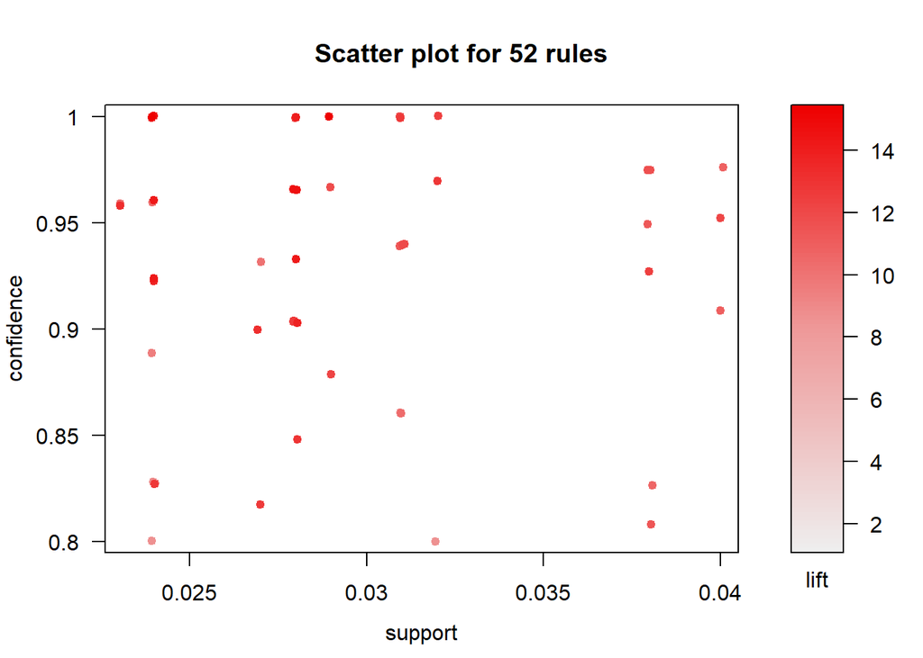

```r
plot(rules.ap)
```

We can see that rules with high lift have typically a relatively low support. The most interesting rules which we present above reside on the large support/confidence regions.

We can also visualize a two-key plot with support and confidence for the x and y-axes and the color of the points representing the number of items in the rule.

```
## To reduce overplotting, jitter is added! Use jitter = 0 to prevent jitter.
```

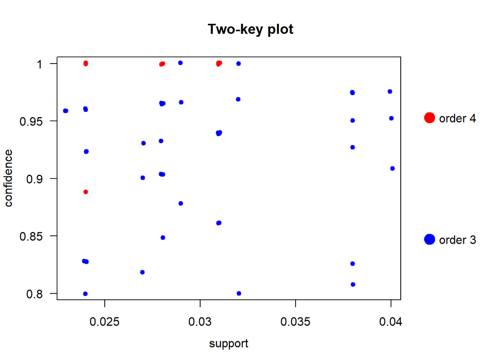

```r
plot(rules.ap, method = "two-key plot")
```

Finally, we can make a graph-based representation, where items and rules are represented as vertices connecting them with directed edges, for a small subset of the 10 rules with the highest lift.

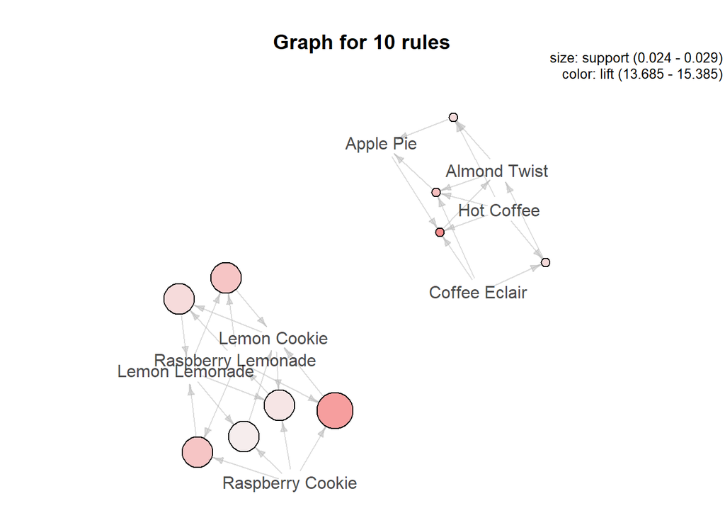

```r
subrules <- head(rules.ap, n = 10, by = "lift")
plot(subrules, method = "graph")
```

Despite of having represented only the 10 rules with highest lift, we can observe the formation of two clusters of items that are commonly purchased together. These is interesting as maybe these subgroups of products can be put in the same advertising campaign.

#### Association Rules using ECLAT

Using the frequent itemsets provided by the function “eclat()” we can determine the positive association rules using the command “ruleInduction()”.

We can now represent the appearance of the different frequent itemsets in the diverse transactions.

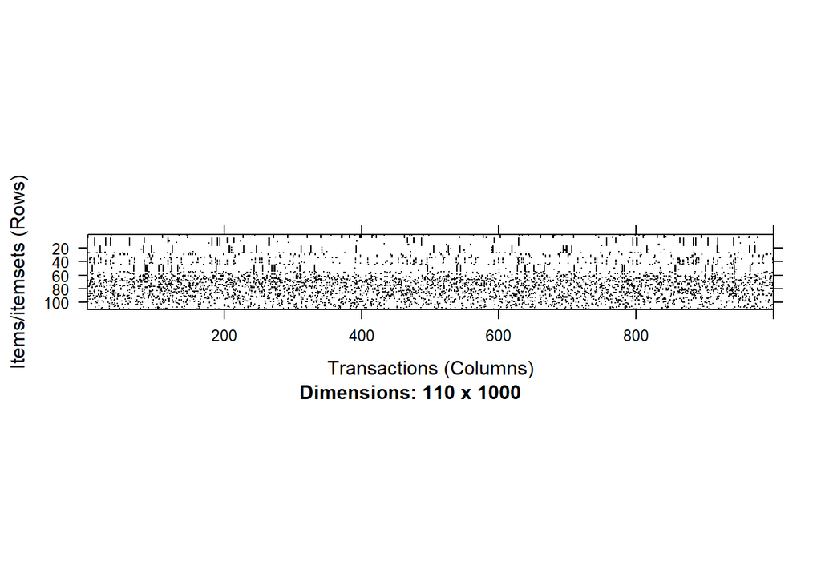

```r
## Inspect visually.
image(tidLists(frequentItems))
```

Now we look for the rules presenting a confidence higher than 0.8 and remove the redundant ones.

```r
rules.ec <- ruleInduction(frequentItems, confidence = 0.8)
#Remove redundant rules
rules.ec <- rules.ec[!is.redundant(rules.ec)]
summary(rules.ec)
```

```
## set of 52 rules
##
## rule length distribution (lhs + rhs):sizes
##  3  4
## 43  9
##
##    Min. 1st Qu.  Median    Mean 3rd Qu.    Max.
##   3.000   3.000   3.000   3.173   3.000   4.000
##
## summary of quality measures:
##     support          confidence          lift
##  Min.   :0.02300   Min.   :0.8000   Min.   : 8.511
##  1st Qu.:0.02400   1st Qu.:0.8972   1st Qu.:10.745
##  Median :0.02800   Median :0.9394   Median :11.898
##  Mean   :0.02948   Mean   :0.9267   Mean   :11.925
##  3rd Qu.:0.03100   3rd Qu.:0.9709   3rd Qu.:12.924
##  Max.   :0.04000   Max.   :1.0000   Max.   :15.385
```

We observe that we get the 52 rules, the same which we obtained with the APRIORI algorithm as expected.

#### Negative Association Rules

We focus now in detecting asssociation rules which take into account items that are part of the domain but that are not together part of a transaction, also known as **negative rules**. For that purpose we define a function that finds negative rules:

```r
negative.rules <- function(transactions.object, positive.rules, itemList, min_support=0.02, min_confidence=0.8, minlen=2, maxlen=10, target="rules"){

  neg.transactions <- addComplement(transactions.object, labels = itemList) #We add the complement of the items in the itemList
  neg.rules <- apriori(neg.transactions, parameter = list(support = min_support,
                                                          confidence = min_confidence,
                                                          minlen  = minlen, #Minimal number of items per item set
                                                          maxlen  = maxlen, #Maximal number of items per item set
                                                          target  = target)
)
  #We remove redundant rules
  neg.rules.pruned <- neg.rules[!is.redundant(neg.rules)]
  #Finally, from the list of rules neg.rules.pruned we can remove the “positive” ones and keep only the “negative” ones.
  positive_lhs=labels(lhs(positive.rules))
  positive_rhs=labels(rhs(positive.rules))
  diff=as.logical(1:length(labels(neg.rules.pruned)))
  #The elements of diff will be TRUE (FALSE) if the rule is a negative (positive).
  for (i in 1:length(positive_lhs)){
   diff=diff & ((labels(lhs(neg.rules.pruned))!=positive_lhs[i])
                |(labels(rhs(neg.rules.pruned))!=positive_rhs[i]))
  }
  good.nar.pruned=neg.rules.pruned[diff]

return(good.nar.pruned)
}
```

As it is a really computationally expensive task we will only focus on finding rules associated to items which produce a higher income, particularly “Truffle Cake” and “Opera Cake”.

```r
itemList <- c("Truffle Cake ", "Opera Cake ")

neg.rules <- negative.rules(transactions.obj, rules.ap, itemList, min_support=0.02, min_confidence=0.8, minlen=2, maxlen=10, target="rules")
```

```
## Apriori
##
## Parameter specification:
##  confidence minval smax arem  aval originalSupport maxtime support minlen
##         0.8    0.1    1 none FALSE            TRUE       5    0.02      2
##  maxlen target   ext
##      10  rules FALSE
##
## Algorithmic control:
##  filter tree heap memopt load sort verbose
##     0.1 TRUE TRUE  FALSE TRUE    2    TRUE
##
## Absolute minimum support count: 20
##
## set item appearances ...[0 item(s)] done [0.00s].
## set transactions ...[52 item(s), 1000 transaction(s)] done [0.00s].
## sorting and recoding items ... [52 item(s)] done [0.00s].
## creating transaction tree ... done [0.00s].
## checking subsets of size 1 2 3 4 5 6 done [0.00s].
## writing ... [623 rule(s)] done [0.00s].
## creating S4 object  ... done [0.00s].
```

```r
neg.rules.lift <- sort (neg.rules, by="lift", decreasing=TRUE)
inspect(head(neg.rules.lift))
```

```
##     lhs                    rhs                  support confidence     lift count
## [1] {Almond Twist ,
##      Coffee Eclair ,
##      !Opera Cake }      => {Apple Pie }           0.027  0.9310345 13.69168    27
## [2] {Apple Pie ,
##      Coffee Eclair ,
##      !Truffle Cake ,
##      !Opera Cake }      => {Almond Twist }        0.027  0.8709677 13.39950    27
## [3] {Lemon Cookie ,
##      Raspberry Cookie ,
##      !Truffle Cake }    => {Lemon Lemonade }      0.028  0.8750000 13.25758    28
## [4] {Blueberry Tart ,
##      Hot Coffee ,
##      !Opera Cake }      => {Apricot Croissant }   0.031  1.0000000 13.15789    31
## [5] {Apple Pie ,
##      Coffee Eclair ,
##      !Truffle Cake }    => {Almond Twist }        0.027  0.8437500 12.98077    27
## [6] {Apple Pie ,
##      Coffee Eclair ,
##      !Opera Cake }      => {Almond Twist }        0.027  0.8437500 12.98077    27
```

Notice that some important rules in the sense of lift appear when considering “negative” association rules. As was the case with positive association rules, we have some interesting rules with a large lift (over 10) and high confidence (over 0.9) while presenting a not insignificant support like the followings:

- Almond Twist, Coffee Eclair, !Opera Cake -> Apple Pie
- Blueberry Tart, Hot Coffee, !Opera Cake -> Apricot Croissant

To conclude we represent the “negative” association rules in a scatter plot.

```
## To reduce overplotting, jitter is added! Use jitter = 0 to prevent jitter.
```

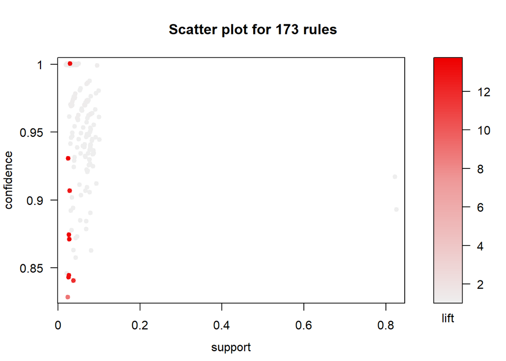

```r
plot(neg.rules)
```

As in the case of the positive association rules, we can observe that rules with a large support also present a low lift, and that high confidence rules also show a low support.

#### Analysis of most sold product

Finally, it might be fruitful to study what customers had bought before buying “Truffle Cake”, which results to be the most expensive item in the stores as well as the second most sold. Therefore, it might be interesting to figure out how can we increase its sales and convert it to the star product of the company. For that purpose we can make an analysis to better understand the patterns that led to the purchase of “Truffle Cake” by looking for rules with “Truffle Cake” in the RHS.

```r
rules1 <- apriori (data=transactions.obj, parameter=list (supp=0.02, conf = 0.5,minlen=2), appearance = list (default="lhs",rhs="Truffle Cake "), control = list (verbose=F)) # get rules that lead to buying 'Truffle Cake'
rules1_conf <- sort (rules1, by="confidence", decreasing=TRUE) # 'high-confidence' rules.
inspect(head(rules1_conf))
```

```
##     lhs                    rhs             support confidence lift     count
## [1] {Gongolais Cookie } => {Truffle Cake } 0.058   0.537037   5.213952 58
```

We conclude that a promotion campaign of “Gongolais Cookie” may result in an increase of the “Truffle Cake” sales, which can result in remarkable profits for the company.

### b) 5,000 Receipts

From now on we will extend the procedure used for the 1,000 receipts data set to the other data sets, but now we will make a more straightforward analysis taking less care about specifying all the details.

#### Exploring the data set

In the first place, we load the data set using the transactions.object() function

```r
dataset = transactions.object("5000/5000i.csv")
transactions.obj <- dataset$transactions.obj
```

Let’s get a little bit of insight on the data set by presenting some statitical information about the transaction object.

```r
summary(transactions.obj)
```

```
## transactions as itemMatrix in sparse format with
##  5000 rows (elements/itemsets/transactions) and
##  50 columns (items) and a density of 0.07094
##
## most frequent items:
##    Coffee Eclair        Hot Coffee      Tuile Cookie   Strawberry Cake
##               554               513               499               480
## Gongolais Cookie            (Other)
##               477             15212
##
## element (itemset/transaction) length distribution:
## sizes
##    1    2    3    4    5    6    7    8
##  248  923 1601 1144  596  237  148  103
##
##    Min. 1st Qu.  Median    Mean 3rd Qu.    Max.
##   1.000   3.000   3.000   3.547   4.000   8.000
##
## includes extended item information - examples:
##              labels
## 1 Almond Bear Claw
## 2 Almond Croissant
## 3      Almond Tart
##
## includes extended transaction information - examples:
##   transactionID
## 1             1
## 2             2
## 3             3
```

We can observe that again the data set is quite sparse presenting a density of 7.094%, that now “Coffee Eclair” is the most sold item and that the average sale consist of 3.547 items.

Now, we can represent in a histogram the 20 most frequent items.

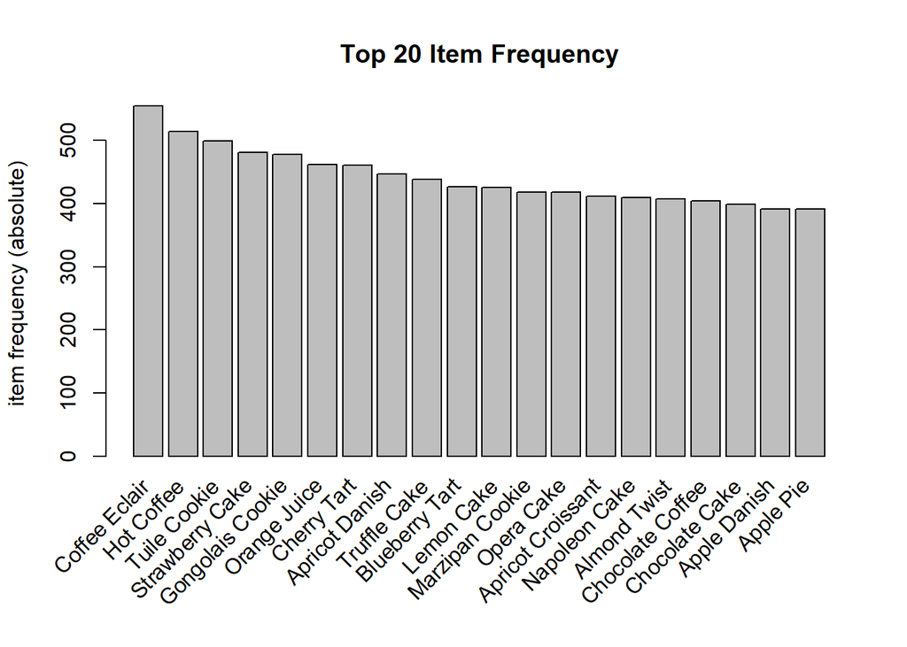

```r
itemFrequencyPlot(transactions.obj, topN=20, type="absolute", main="Top 20 Item Frequency")
```

From this representation we observe that there is not a great unbalance in the number of sales between the different items.

#### Most frequent itemsets

As we did with the 1000 items dataset, we are going to look for frequent itemsets using the “eclat()” function with a mininum support of 0.02 .

```r
frequentItems <- eclat(transactions.obj, parameter = list(support = 0.02, tidLists = TRUE))
```

```r
##Show the Frequent itemsets and respectives supports
inspect(frequentItems)
```

```
##       items                  support count
## [1]   {Blackberry Tart ,
##        Coffee Eclair ,
##        Single Espresso }      0.0286   143
## [2]   {Coffee Eclair ,
##        Single Espresso }      0.0296   148
## [3]   {Blackberry Tart ,
##        Single Espresso }      0.0314   157
## [4]   {Lemon Cake ,
##        Lemon Tart }           0.0336   168
## [5]   {Apple Croissant ,
##        Apple Danish ,
##        Apple Tart ,
##        Cherry Soda }          0.0228   114
## [6]   {Apple Danish ,
##        Apple Tart ,
##        Cherry Soda }          0.0228   114
## [7]   {Apple Croissant ,
##        Apple Tart ,
##        Cherry Soda }          0.0230   115
## [8]   {Apple Croissant ,
##        Apple Danish ,
##        Cherry Soda }          0.0230   115
## [9]   {Apple Danish ,
##        Cherry Soda }          0.0250   125
## [10]  {Apple Croissant ,
##        Cherry Soda }          0.0252   126
## [11]  {Apple Tart ,
##        Cherry Soda }          0.0254   127
## [12]  {Chocolate Tart ,
##        Vanilla Frappuccino ,
##        Walnut Cookie }        0.0266   133
## [13]  {Chocolate Tart ,
##        Walnut Cookie }        0.0286   143
## [14]  {Vanilla Frappuccino ,
##        Walnut Cookie }        0.0298   149
## [15]  {Green Tea ,
##        Lemon Cookie ,
##        Lemon Lemonade ,
##        Raspberry Cookie ,
```

[output cut: 184 more lines]

```
## [110] {Cherry Soda }          0.0670   335
## [111] {Lemon Tart }           0.0708   354
## [112] {Single Espresso }      0.0654   327
## [113] {Vanilla Eclair }       0.0460   230
## [114] {Chocolate Meringue }   0.0452   226
## [115] {Almond Croissant }     0.0456   228
## [116] {Almond Bear Claw }     0.0428   214
## [117] {Chocolate Croissant }  0.0432   216
## [118] {Pecan Tart }           0.0444   222
## [119] {Blueberry Danish }     0.0400   200
## [120] {Apricot Tart }         0.0422   211
## [121] {Vanilla Meringue }     0.0398   199
## [122] {Ganache Cookie }       0.0388   194
## [123] {Chocolate Eclair }     0.0382   191
## [124] {Almond Tart }          0.0386   193
```

Let’s summarize all these frequent itemsets.

```r
summary(frequentItems)
```

```
## set of 124 itemsets
##
## most frequent items:
##          Green Tea        Lemon Cookie      Lemon Lemonade    Raspberry Cookie
##                  16                  16                  16                  16
## Raspberry Lemonade              (Other)
##                  16                 158
##
## element (itemset/transaction) length distribution:sizes
##  1  2  3  4  5
## 50 43 23  7  1
##
##    Min. 1st Qu.  Median    Mean 3rd Qu.    Max.
##   1.000   1.000   2.000   1.919   2.250   5.000
##
## summary of quality measures:
##     support           count
##  Min.   :0.0212   Min.   :106.0
##  1st Qu.:0.0283   1st Qu.:141.5
##  Median :0.0384   Median :192.0
##  Mean   :0.0469   Mean   :234.5
##  3rd Qu.:0.0685   3rd Qu.:342.5
##  Max.   :0.1108   Max.   :554.0
##
## includes transaction ID lists: TRUE
##
## mining info:
##              data ntransactions support
##  transactions.obj          5000    0.02
```

#### Association Rules using APRIORI

We aim now to find rules using the APRIORI algorithm. We are going to look for rules with a minimum support of 0.02 and a minimum confidence of 0.8.

```r
#We require minlen 2 to avoid having rules with only 1 consequent and 0 antecedent
rules.ap <- apriori(transactions.obj, parameter = list(supp = 0.02, conf = 0.8, minlen=2))
```

```
## Apriori
##
## Parameter specification:
##  confidence minval smax arem  aval originalSupport maxtime support minlen
##         0.8    0.1    1 none FALSE            TRUE       5    0.02      2
##  maxlen target   ext
##      10  rules FALSE
##
## Algorithmic control:
##  filter tree heap memopt load sort verbose
##     0.1 TRUE TRUE  FALSE TRUE    2    TRUE
##
## Absolute minimum support count: 100
##
## set item appearances ...[0 item(s)] done [0.00s].
## set transactions ...[50 item(s), 5000 transaction(s)] done [0.00s].
## sorting and recoding items ... [50 item(s)] done [0.00s].
## creating transaction tree ... done [0.00s].
## checking subsets of size 1 2 3 4 5 done [0.00s].
## writing ... [85 rule(s)] done [0.00s].
## creating S4 object  ... done [0.00s].
```

We have obtained 85 rules, however some of them provide no extra information related to others. These are called **redudant rules** and we can find them automatically.

```r
inspect(rules.ap[is.redundant(rules.ap)])
```

```
##     lhs                      rhs                   support confidence     lift count
## [1] {Green Tea ,
##      Lemon Cookie ,
##      Lemon Lemonade ,
##      Raspberry Cookie }   => {Raspberry Lemonade }  0.0212  1.0000000 14.74926   106
## [2] {Green Tea ,
##      Lemon Lemonade ,
##      Raspberry Cookie ,
##      Raspberry Lemonade } => {Lemon Cookie }        0.0212  1.0000000 15.57632   106
## [3] {Green Tea ,
##      Lemon Cookie ,
##      Lemon Lemonade ,
##      Raspberry Lemonade } => {Raspberry Cookie }    0.0212  1.0000000 15.62500   106
## [4] {Green Tea ,
##      Lemon Cookie ,
##      Raspberry Cookie ,
##      Raspberry Lemonade } => {Lemon Lemonade }      0.0212  1.0000000 15.43210   106
## [5] {Lemon Cookie ,
##      Lemon Lemonade ,
##      Raspberry Cookie ,
##      Raspberry Lemonade } => {Green Tea }           0.0212  0.8091603 13.05097   106
```

Therefore, we are going to prune those redudant rules from our list of positive rules, so we get 80 rules.

```r
#Remove redundant rules
rules.ap <- rules.ap[!is.redundant(rules.ap)]
```

Let’s get now some statistical information on the rules.

```r
summary(rules.ap)
```

```
## set of 80 rules
##
## rule length distribution (lhs + rhs):sizes
##  3  4
## 53 27
##
##    Min. 1st Qu.  Median    Mean 3rd Qu.    Max.
##   3.000   3.000   3.000   3.337   4.000   4.000
##
## summary of quality measures:
##     support          confidence          lift            count
##  Min.   :0.02120   Min.   :0.8030   Min.   : 7.859   Min.   :106.0
##  1st Qu.:0.02120   1st Qu.:0.9118   1st Qu.:11.823   1st Qu.:106.0
##  Median :0.02620   Median :0.9251   Median :13.443   Median :131.0
##  Mean   :0.02602   Mean   :0.9324   Mean   :13.041   Mean   :130.1
##  3rd Qu.:0.02980   3rd Qu.:0.9907   3rd Qu.:14.522   3rd Qu.:149.0
##  Max.   :0.04080   Max.   :1.0000   Max.   :15.625   Max.   :204.0
##
## mining info:
##              data ntransactions support confidence
##  transactions.obj          5000    0.02        0.8
```

We observe that all the rules present both large values of confidence, with a mean of 0.9324, and lift, with a mean of 13.041 . Also, we only have rules with 3 items (53 cases) and 4 items (27 cases), being 3.337 items the average.

So, let’s now classify the rules by lift:

```r
#High lift rules
rules.lift <- sort (rules.ap, by="lift", decreasing=TRUE)
inspect(head(rules.lift)) # show the support, lift and confidence for higher lift rules
```

```
##     lhs                      rhs                 support confidence     lift count
## [1] {Green Tea ,
##      Lemon Lemonade ,
##      Raspberry Lemonade } => {Raspberry Cookie }  0.0212          1 15.62500   106
## [2] {Green Tea ,
##      Lemon Cookie ,
##      Raspberry Lemonade } => {Raspberry Cookie }  0.0212          1 15.62500   106
## [3] {Green Tea ,
##      Lemon Lemonade ,
##      Raspberry Cookie }   => {Lemon Cookie }      0.0212          1 15.57632   106
## [4] {Green Tea ,
##      Lemon Lemonade ,
##      Raspberry Lemonade } => {Lemon Cookie }      0.0212          1 15.57632   106
## [5] {Green Tea ,
##      Raspberry Cookie ,
##      Raspberry Lemonade } => {Lemon Cookie }      0.0212          1 15.57632   106
## [6] {Lemon Lemonade ,
##      Raspberry Cookie ,
##      Raspberry Lemonade } => {Lemon Cookie }      0.0262          1 15.57632   131
```

Then, let’s classify the rules by confidence:

```r
#High confidence rules
rules.confidence <- sort (rules.ap, by="confidence", decreasing=TRUE)
inspect(head(rules.confidence)) # show the support, lift and confidence for high confidence rules
```

```
##     lhs                      rhs                   support confidence     lift count
## [1] {Apple Danish ,
##      Apple Tart ,
##      Cherry Soda }        => {Apple Croissant }     0.0228          1 13.47709   114
## [2] {Green Tea ,
##      Lemon Lemonade ,
##      Raspberry Cookie }   => {Lemon Cookie }        0.0212          1 15.57632   106
## [3] {Green Tea ,
##      Lemon Lemonade ,
##      Raspberry Cookie }   => {Raspberry Lemonade }  0.0212          1 14.74926   106
## [4] {Green Tea ,
##      Lemon Lemonade ,
##      Raspberry Lemonade } => {Raspberry Cookie }    0.0212          1 15.62500   106
## [5] {Green Tea ,
##      Raspberry Cookie ,
##      Raspberry Lemonade } => {Lemon Lemonade }      0.0212          1 15.43210   106
## [6] {Green Tea ,
##      Lemon Lemonade ,
##      Raspberry Lemonade } => {Lemon Cookie }        0.0212          1 15.57632   106
```

The rules with a confidence of 1 mean that, whenever the LHS item was purchased, the RHS item was always purchased. We notice that lift and confidence give as more important rules those which are quite infrequent. Consequently, we will also classify the rules according to support:

```r
#High support rules
rules.support <- sort (rules.ap, by="support", decreasing=TRUE)

inspect(head(rules.support)) # show the support, lift and confidence for high support rules
```

```
##     lhs                                 rhs               support confidence
## [1] {Apricot Danish ,Opera Cake }    => {Cherry Tart }    0.0408  0.9444444
## [2] {Cherry Tart ,Opera Cake }       => {Apricot Danish } 0.0408  0.9357798
## [3] {Almond Twist ,Apple Pie }       => {Coffee Eclair }  0.0382  0.9695431
## [4] {Apple Pie ,Coffee Eclair }      => {Almond Twist }   0.0382  0.9408867
## [5] {Almond Twist ,Coffee Eclair }   => {Apple Pie }      0.0382  0.9271845
## [6] {Apricot Croissant ,Hot Coffee } => {Blueberry Tart } 0.0328  0.9425287
##     lift      count
## [1] 10.265700 204
## [2] 10.490805 204
## [3]  8.750389 191
## [4] 11.558805 191
## [5] 11.856579 191
## [6] 11.062544 164
```

  Notice that these rules might be the most interesting ones as the occur much more frequently than the above mentioned while keeping large values of lift and confidence.

#### Rules visualization

We are going to use different visualization techniques implemented in the library “arulesViz”.

Firstly, we are using a scatter plot using support and confidence on the axes, and lift as the color value.

```
## To reduce overplotting, jitter is added! Use jitter = 0 to prevent jitter.
```

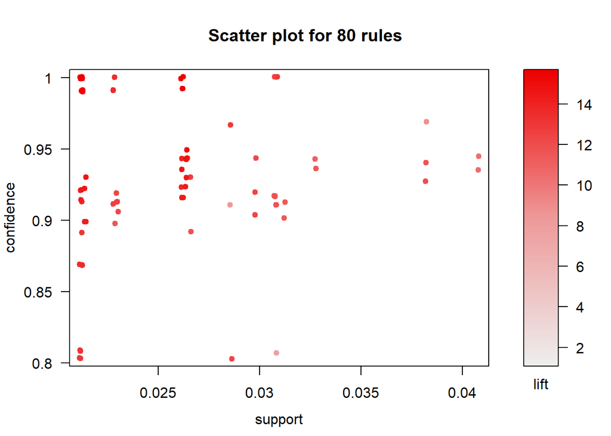

```r
plot(rules.ap)
```

We can see again that rules with high lift have typically a relatively low support. The most interesting rules which we present above reside on the large support/confidence regions. Also notice that the vast majority of rules present large values of confidence (over 0.9).

We can also visualize a two-key plot with support and confidence for the x and y-axes and the color of the points representing the number of items in the rule.

```
## To reduce overplotting, jitter is added! Use jitter = 0 to prevent jitter.
```

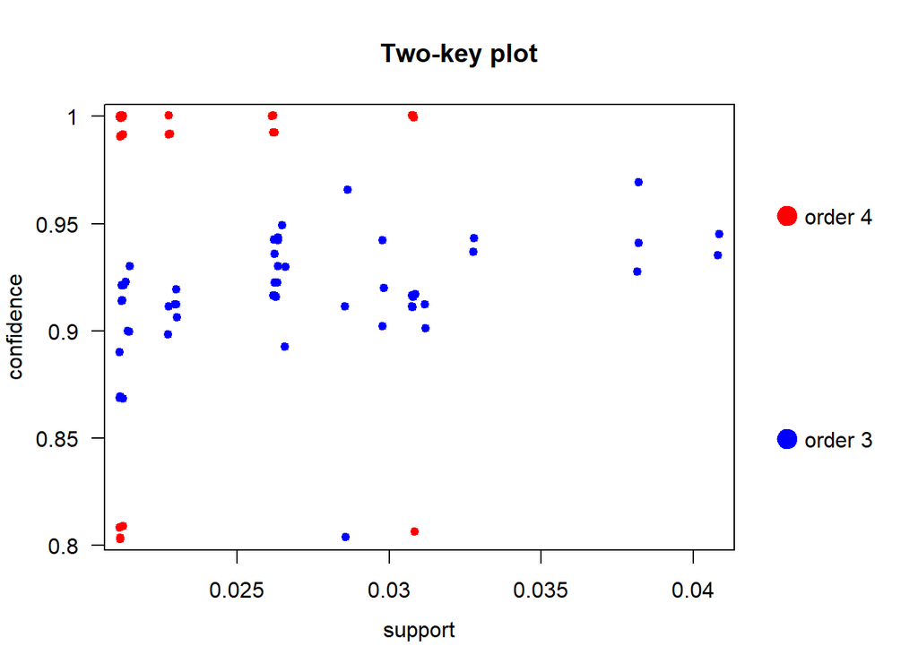

```r
plot(rules.ap, method = "two-key plot")
```

From this representation we observe that simpler rules usually present a larger support than more complex rules, but the later ones show higher confidence.

Finally, we can make a graph-based representation, where items and rules are represented as vertices connecting them with directed edges, for a small subset of the 10 rules with the highest lift.

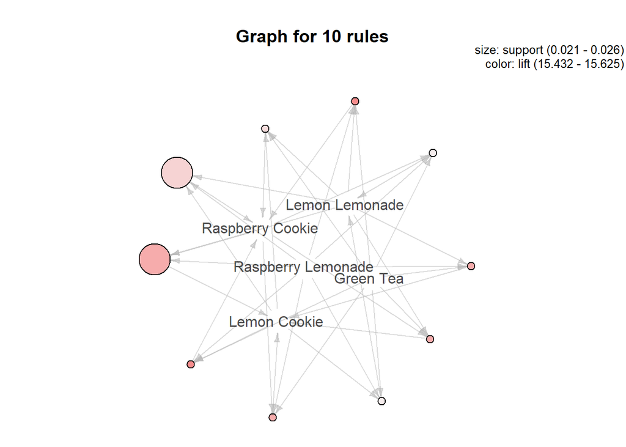

```r
subrules <- head(rules.ap, n = 10, by = "lift")
plot(subrules, method = "graph")
```

Despite of having represented only the 10 rules with highest lift, we can observe the formation of one cluster of items that are commonly purchased together. This fact was noted before and thus we can observe a pretty representation of the relation among the items with highest lift.

#### Association Rules using ECLAT

Using the frequent itemsets provided by the function “eclat()” we can determine the positive association rules using the command “ruleInduction()”.

```r
## Coerce tidLists to list.
as(tidLists(frequentItems), "list")
```

Now we look for the rules presenting a confidence higher than 0.8 and remove the redundant ones.

```r
rules.ec <- ruleInduction(frequentItems, confidence = 0.8)
#Remove redundant rules
rules.ec <- rules.ec[!is.redundant(rules.ec)]
summary(rules.ec)
```

```
## set of 80 rules
##
## rule length distribution (lhs + rhs):sizes
##  3  4
## 53 27
##
##    Min. 1st Qu.  Median    Mean 3rd Qu.    Max.
##   3.000   3.000   3.000   3.337   4.000   4.000
##
## summary of quality measures:
##     support          confidence          lift
##  Min.   :0.02120   Min.   :0.8030   Min.   : 7.859
##  1st Qu.:0.02120   1st Qu.:0.9118   1st Qu.:11.823
##  Median :0.02620   Median :0.9251   Median :13.443
##  Mean   :0.02602   Mean   :0.9324   Mean   :13.041
##  3rd Qu.:0.02980   3rd Qu.:0.9907   3rd Qu.:14.522
##  Max.   :0.04080   Max.   :1.0000   Max.   :15.625
```

We observe that we get the 80 rules, the same which we obtained with the APRIORI algorithm as expected.

#### Negative Association Rules

We focus now in detecting asssociation rules which take into account items that are part of the domain but that are not together part of a transaction, also known as **negative rules**. For that purpose we use the already defined function negative.rules(). As it is a really computationally expensive task we will only focus on finding rules associated to items which produce a higher income, particularly “Truffle Cake” and “Opera Cake”.

```r
itemList <- c("Truffle Cake ", "Opera Cake ")

neg.rules <- negative.rules(transactions.obj, rules.ap, itemList, min_support=0.02, min_confidence=0.8, minlen=2, maxlen=10, target="rules")
```

```
## Apriori
##
## Parameter specification:
##  confidence minval smax arem  aval originalSupport maxtime support minlen
##         0.8    0.1    1 none FALSE            TRUE       5    0.02      2
##  maxlen target   ext
##      10  rules FALSE
##
## Algorithmic control:
##  filter tree heap memopt load sort verbose
##     0.1 TRUE TRUE  FALSE TRUE    2    TRUE
##
## Absolute minimum support count: 100
##
## set item appearances ...[0 item(s)] done [0.00s].
## set transactions ...[52 item(s), 5000 transaction(s)] done [0.00s].
## sorting and recoding items ... [52 item(s)] done [0.00s].
## creating transaction tree ... done [0.00s].
## checking subsets of size 1 2 3 4 5 6 7 done [0.00s].
## writing ... [808 rule(s)] done [0.00s].
## creating S4 object  ... done [0.00s].
```

```r
neg.rules.lift <- sort (neg.rules, by="lift", decreasing=TRUE)
inspect(head(neg.rules.lift))
```

```
##     lhs                    rhs                 support confidence     lift count
## [1] {Lemon Lemonade ,
##      Raspberry Cookie ,
##      !Truffle Cake }    => {Lemon Cookie }      0.0264  0.9635036 15.00785   132
## [2] {Lemon Cookie ,
##      Lemon Lemonade ,
##      !Truffle Cake }    => {Raspberry Cookie }  0.0264  0.9496403 14.83813   132
## [3] {Green Tea ,
##      Lemon Lemonade ,
##      !Truffle Cake }    => {Lemon Cookie }      0.0214  0.9469027 14.74926   107
## [4] {Green Tea ,
##      Raspberry Cookie ,
##      !Opera Cake }      => {Lemon Cookie }      0.0214  0.9469027 14.74926   107
## [5] {Green Tea ,
##      Lemon Lemonade ,
##      !Truffle Cake }    => {Raspberry Cookie }  0.0212  0.9380531 14.65708   106
## [6] {Lemon Cookie ,
##      Raspberry Cookie ,
##      !Opera Cake }      => {Lemon Lemonade }    0.0264  0.9496403 14.65494   132
```

To conclude we represent the “negative” association rules in a scatter plot.

```
## To reduce overplotting, jitter is added! Use jitter = 0 to prevent jitter.
```

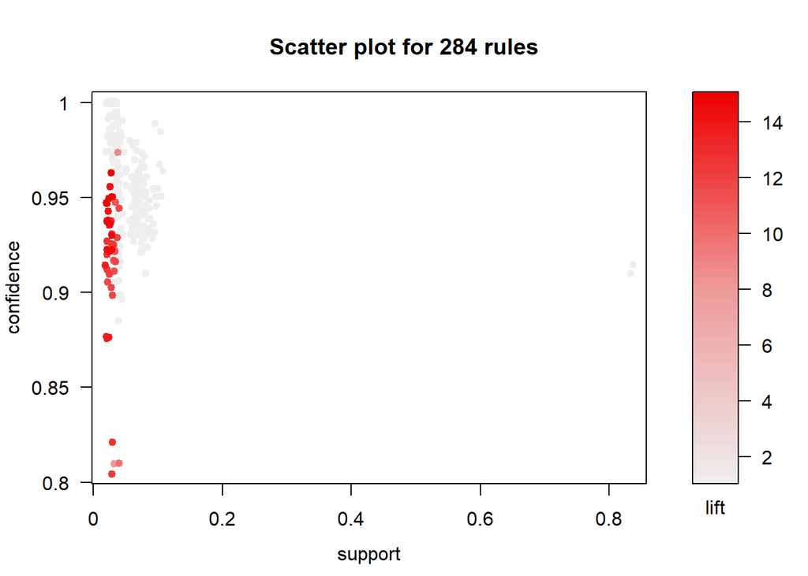

```r
plot(neg.rules)
```

As in the case of the positive association rules, we can observe that rules with a large support also present a low lift (a lift of nearly 1 means that this rules are providing no extra information with respect to random appearance), and that really high confidence rules also show a low support.

#### Analysis of most sold product

Finally, suppose that our company whats to make “Hot Coffee” the star product of the brand and compete with Starbucks. Then, it might be fruitful to study what customers had bought before buying “Hot Coffee”, which actually is the second item with more sales. For that purpose we can make an analysis to better understand the patterns that led to the purchase of “Hot Coffee” by looking for rules with “Hot Coffee” in the RHS.

```r
rules1 <- apriori (data=transactions.obj, parameter=list (supp=0.01, conf = 0.5,minlen=2), appearance = list (default="lhs",rhs="Hot Coffee "), control = list (verbose=F)) # get rules that lead to buying 'Truffle Cake'
rules1_conf <- sort (rules1, by="confidence", decreasing=TRUE) # 'high-confidence' rules.
inspect(head(rules1_conf))
```

```
##     lhs                     rhs           support confidence     lift count
## [1] {Almond Twist ,
##      Apple Pie ,
##      Coffee Eclair }     => {Hot Coffee }  0.0308  0.8062827 7.858506   154
## [2] {Almond Twist ,
##      Apple Pie }         => {Hot Coffee }  0.0308  0.7817259 7.619161   154
## [3] {Apple Pie ,
##      Coffee Eclair }     => {Hot Coffee }  0.0308  0.7586207 7.393964   154
## [4] {Almond Twist ,
##      Coffee Eclair }     => {Hot Coffee }  0.0308  0.7475728 7.286285   154
## [5] {Apricot Croissant ,
##      Blueberry Tart }    => {Hot Coffee }  0.0328  0.7454545 7.265639   164
```

We conclude that a promotion campaign of a pack of “Almond Twist”, “Apple Pie” and “Coffee Eclair” may result in an increase of the “Hot Coffee” sales, which can result in remarkable profits for the company.

### c) 20,000 Receipts

#### Exploring the data set

In the first place, we load the data set using the transactions.object() function

```r
dataset = transactions.object("20000/20000i.csv")
transactions.obj <- dataset$transactions.obj
```

Let’s get a little bit of insight on the data set by presenting some statistical information about the transaction object.

```r
summary(transactions.obj)
```

```
## transactions as itemMatrix in sparse format with
##  20000 rows (elements/itemsets/transactions) and
##  50 columns (items) and a density of 0.07113
##
## most frequent items:
##  Coffee Eclair      Hot Coffee    Tuile Cookie  Apricot Danish    Orange Juice
##            2197            2072            1973            1854            1848
##         (Other)
##           61186
##
## element (itemset/transaction) length distribution:
## sizes
##    1    2    3    4    5    6    7    8
##  934 3612 6570 4555 2305 1044  587  393
##
##    Min. 1st Qu.  Median    Mean 3rd Qu.    Max.
##   1.000   3.000   3.000   3.557   4.000   8.000
##
## includes extended item information - examples:
##              labels
## 1 Almond Bear Claw
## 2 Almond Croissant
## 3      Almond Tart
##
## includes extended transaction information - examples:
##   transactionID
## 1             1
## 2             2
## 3             3
```

We can observe that again the data set is quite sparse presenting a density of 7.113%, that again “Coffee Eclair” is the most sold item and that the average sale consist of 3.557 items.

Now, we can represent in a histogram the 20 most frequent items.

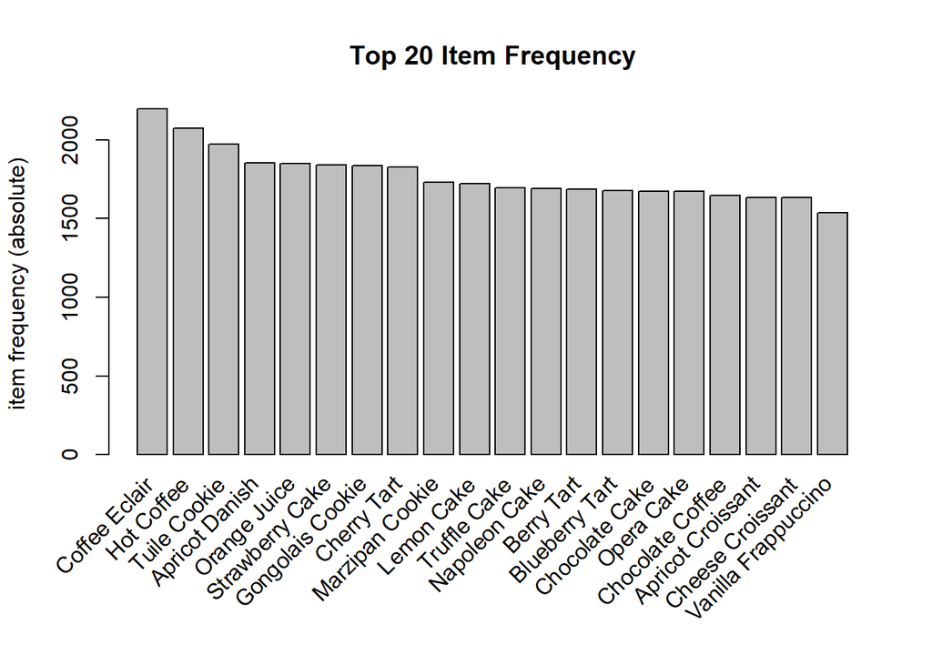

```r
itemFrequencyPlot(transactions.obj, topN=20, type="absolute", main="Top 20 Item Frequency")
```

#### Most frequent itemsets

As we did with the 1000 items dataset, we are going to look for frequent itemsets using the “eclat()” function with a mininum support of 0.02 .

```r
frequentItems <- eclat(transactions.obj, parameter = list(support = 0.02, tidLists = TRUE))
```

```r
##Show the Frequent itemsets and respectives supports
inspect(frequentItems)
```

```
##       items                  support count
## [1]   {Berry Tart ,
##        Bottled Water }       0.03570   714
## [2]   {Green Tea ,
##        Lemon Cookie ,
##        Lemon Lemonade ,
##        Raspberry Cookie ,
##        Raspberry Lemonade }  0.02040   408
## [3]   {Green Tea ,
##        Lemon Lemonade ,
##        Raspberry Cookie ,
##        Raspberry Lemonade }  0.02045   409
## [4]   {Green Tea ,
##        Lemon Cookie ,
##        Lemon Lemonade ,
##        Raspberry Lemonade }  0.02045   409
## [5]   {Green Tea ,
##        Lemon Cookie ,
##        Lemon Lemonade ,
##        Raspberry Cookie }    0.02040   408
## [6]   {Green Tea ,
##        Lemon Lemonade ,
##        Raspberry Cookie }    0.02065   413
## [7]   {Green Tea ,
##        Lemon Cookie ,
##        Lemon Lemonade }      0.02055   411
## [8]   {Green Tea ,
##        Lemon Lemonade ,
##        Raspberry Lemonade }  0.02055   411
## [9]   {Green Tea ,
##        Lemon Cookie ,
##        Raspberry Cookie ,
##        Raspberry Lemonade }  0.02040   408
## [10]  {Green Tea ,
##        Raspberry Cookie ,
##        Raspberry Lemonade }  0.02050   410
## [11]  {Green Tea ,
##        Lemon Cookie ,
##        Raspberry Lemonade }  0.02055   411
## [12]  {Green Tea ,
```

[output cut: 184 more lines]

```
## [110] {Cherry Soda }         0.06530  1306
## [111] {Green Tea }           0.06215  1243
## [112] {Bottled Water }       0.07215  1443
## [113] {Chocolate Croissant } 0.04460   892
## [114] {Almond Bear Claw }    0.04425   885
## [115] {Chocolate Meringue }  0.04450   890
## [116] {Ganache Cookie }      0.04330   866
## [117] {Apricot Tart }        0.04275   855
## [118] {Vanilla Eclair }      0.04270   854
## [119] {Pecan Tart }          0.04155   831
## [120] {Vanilla Meringue }    0.04240   848
## [121] {Blueberry Danish }    0.04115   823
## [122] {Almond Croissant }    0.04205   841
## [123] {Chocolate Eclair }    0.04260   852
## [124] {Almond Tart }         0.04055   811
```

Let’s summarize all these frequent itemsets.

```r
summary(frequentItems)
```

```
## set of 124 itemsets
##
## most frequent items:
##          Green Tea        Lemon Cookie      Lemon Lemonade    Raspberry Cookie
##                  16                  16                  16                  16
## Raspberry Lemonade              (Other)
##                  16                 158
##
## element (itemset/transaction) length distribution:sizes
##  1  2  3  4  5
## 50 43 23  7  1
##
##    Min. 1st Qu.  Median    Mean 3rd Qu.    Max.
##   1.000   1.000   2.000   1.919   2.250   5.000
##
## summary of quality measures:
##     support            count
##  Min.   :0.02040   Min.   : 408.0
##  1st Qu.:0.02775   1st Qu.: 555.0
##  Median :0.03687   Median : 737.5
##  Mean   :0.04646   Mean   : 929.2
##  3rd Qu.:0.06930   3rd Qu.:1386.0
##  Max.   :0.10985   Max.   :2197.0
##
## includes transaction ID lists: TRUE
##
## mining info:
##              data ntransactions support
##  transactions.obj         20000    0.02
```

#### Association Rules using APRIORI

We aim now to find rules using the APRIORI algorithm. We are going to look for rules with a minimum support of 0.02 and a minimum confidence of 0.8.

```r
#We require minlen 2 to avoid having rules with only 1 consequent and 0 antecedent
rules.ap <- apriori(transactions.obj, parameter = list(supp = 0.02, conf = 0.8, minlen=2))
```

```
## Apriori
##
## Parameter specification:
##  confidence minval smax arem  aval originalSupport maxtime support minlen
##         0.8    0.1    1 none FALSE            TRUE       5    0.02      2
##  maxlen target   ext
##      10  rules FALSE
##
## Algorithmic control:
##  filter tree heap memopt load sort verbose
##     0.1 TRUE TRUE  FALSE TRUE    2    TRUE
##
## Absolute minimum support count: 400
##
## set item appearances ...[0 item(s)] done [0.00s].
## set transactions ...[50 item(s), 20000 transaction(s)] done [0.01s].
## sorting and recoding items ... [50 item(s)] done [0.00s].
## creating transaction tree ... done [0.01s].
## checking subsets of size 1 2 3 4 5 done [0.00s].
## writing ... [81 rule(s)] done [0.00s].
## creating S4 object  ... done [0.00s].
```

We have obtained 81 rules, however some of them provide no extra information related to others. These are called **redudant rules** and we can find them automatically.

```r
inspect(rules.ap[is.redundant(rules.ap)])
```

We observe that there are no redudant rules. Let’s get now some statistical information on the rules.

```r
summary(rules.ap)
```

```
## set of 81 rules
##
## rule length distribution (lhs + rhs):sizes
##  3  4  5
## 52 24  5
##
##    Min. 1st Qu.  Median    Mean 3rd Qu.    Max.
##    3.00    3.00    3.00    3.42    4.00    5.00
##
## summary of quality measures:
##     support          confidence          lift            count
##  Min.   :0.02040   Min.   :0.8016   Min.   : 7.942   Min.   :408.0
##  1st Qu.:0.02055   1st Qu.:0.9128   1st Qu.:12.533   1st Qu.:411.0
##  Median :0.02545   Median :0.9225   Median :13.407   Median :509.0
##  Mean   :0.02471   Mean   :0.9380   Mean   :13.015   Mean   :494.1
##  3rd Qu.:0.02810   3rd Qu.:0.9927   3rd Qu.:14.294   3rd Qu.:562.0
##  Max.   :0.04100   Max.   :1.0000   Max.   :15.026   Max.   :820.0
##
## mining info:
##              data ntransactions support confidence
##  transactions.obj         20000    0.02        0.8
```

We observe that all the rules present both large values of confidence, with a mean of 0.9380, and lift, with a mean of 13.015 . Also, we see that now we have rules with 5 items (5 cases), 4 items (24 cases) and 3 items (52 cases), being 3.42 items the average.

So, let’s now classify the rules by lift:

```r
#High lift rules
rules.lift <- sort (rules.ap, by="lift", decreasing=TRUE)
inspect(head(rules.lift)) # show the support, lift and confidence for higher lift rules
```

```
##     lhs                      rhs               support confidence     lift count
## [1] {Green Tea ,
##      Lemon Cookie ,
##      Raspberry Cookie ,
##      Raspberry Lemonade } => {Lemon Lemonade } 0.02040  1.0000000 15.02630   408
## [2] {Green Tea ,
##      Raspberry Cookie ,
##      Raspberry Lemonade } => {Lemon Lemonade } 0.02045  0.9975610 14.98965   409
## [3] {Green Tea ,
##      Lemon Cookie ,
##      Raspberry Lemonade } => {Lemon Lemonade } 0.02045  0.9951338 14.95318   409
## [4] {Lemon Cookie ,
##      Raspberry Cookie ,
##      Raspberry Lemonade } => {Lemon Lemonade } 0.02545  0.9941406 14.93825   509
## [5] {Green Tea ,
##      Lemon Cookie ,
##      Raspberry Cookie }   => {Lemon Lemonade } 0.02040  0.9927007 14.91662   408
## [6] {Apple Croissant ,
##      Apple Tart ,
##      Cherry Soda }        => {Apple Danish }   0.02100  0.9929078 14.69886   420
```

Then, let’s classify the rules by confidence:

```r
#High confidence rules
rules.confidence <- sort (rules.ap, by="confidence", decreasing=TRUE)
inspect(head(rules.confidence)) # show the support, lift and confidence for high confidence rules
```

```
##     lhs                      rhs                   support confidence     lift count
## [1] {Green Tea ,
##      Lemon Cookie ,
##      Lemon Lemonade ,
##      Raspberry Cookie }   => {Raspberry Lemonade } 0.02040  1.0000000 14.60920   408
## [2] {Green Tea ,
##      Lemon Cookie ,
##      Raspberry Cookie ,
##      Raspberry Lemonade } => {Lemon Lemonade }     0.02040  1.0000000 15.02630   408
## [3] {Almond Twist ,
##      Coffee Eclair ,
##      Hot Coffee }         => {Apple Pie }          0.02810  0.9982238 13.46222   562
## [4] {Green Tea ,
##      Raspberry Cookie ,
##      Raspberry Lemonade } => {Lemon Lemonade }     0.02045  0.9975610 14.98965   409
## [5] {Green Tea ,
##      Lemon Cookie ,
##      Lemon Lemonade ,
##      Raspberry Lemonade } => {Raspberry Cookie }   0.02040  0.9975550 14.36364   408
## [6] {Green Tea ,
##      Lemon Lemonade ,
##      Raspberry Cookie ,
##      Raspberry Lemonade } => {Lemon Cookie }       0.02040  0.9975550 14.61619   408
```

The rules with a confidence of 1 mean that, whenever the LHS item was purchased, the RHS item was always purchased. We notice that lift and confidence give as more important rules those which are quite infrequent. Consequently, we will also classify the rules according to support:

```r
#High support rules
rules.support <- sort (rules.ap, by="support", decreasing=TRUE)

inspect(head(rules.support)) # show the support, lift and confidence for high support rules
```

```
##     lhs                                 rhs               support confidence
## [1] {Cherry Tart ,Opera Cake }       => {Apricot Danish } 0.04100 0.9392898
## [2] {Apricot Danish ,Opera Cake }    => {Cherry Tart }    0.04100 0.9457901
## [3] {Almond Twist ,Apple Pie }       => {Coffee Eclair }  0.03415 0.9499305
## [4] {Almond Twist ,Coffee Eclair }   => {Apple Pie }      0.03415 0.9420690
## [5] {Apple Pie ,Coffee Eclair }      => {Almond Twist }   0.03415 0.9167785
## [6] {Casino Cake ,Chocolate Coffee } => {Chocolate Cake } 0.03390 0.9495798
##     lift      count
## [1] 10.132576 820
## [2] 10.364823 820
## [3]  8.647524 683
## [4] 12.704909 683
## [5] 12.532857 683
## [6] 11.351821 678
```

From the rules found we can point out the following:

  Notice that these rules might be the most interesting ones as the occur much more frequently than the above mentioned while keeping large values of lift and confidence.

#### Rules visualization

We are going to use different visualization techniques implemented in the library “arulesViz”.

Firstly, we are using a scatter plot using support and confidence on the axes, and lift as the color value.

```
## To reduce overplotting, jitter is added! Use jitter = 0 to prevent jitter.
```

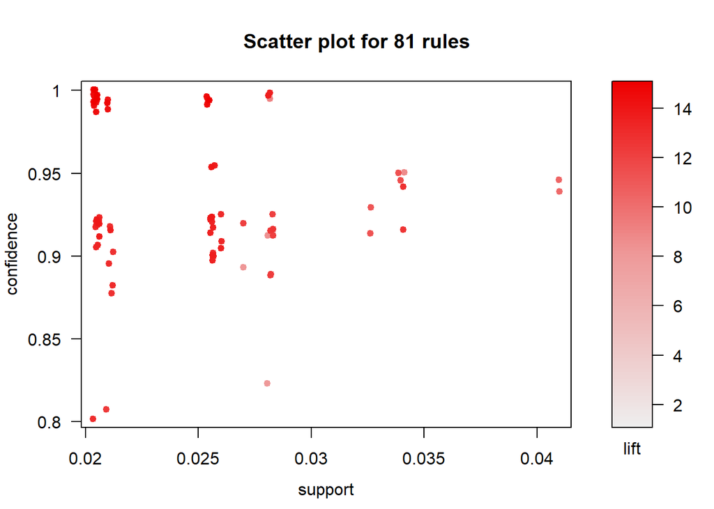

```r
plot(rules.ap)
```

The most interesting rules which we present above reside on the large support/confidence regions. Also notice that the vast majority of rules present large values of confidence (over 0.9). It is quite fascinating to observe the formation of clusters of rules, which are consituted by closed itemsets of items forming new rules from permutations of themselves.

We can also visualize a two-key plot with support and confidence for the x and y-axes and the color of the points representing the number of items in the rule.

```
## To reduce overplotting, jitter is added! Use jitter = 0 to prevent jitter.
```

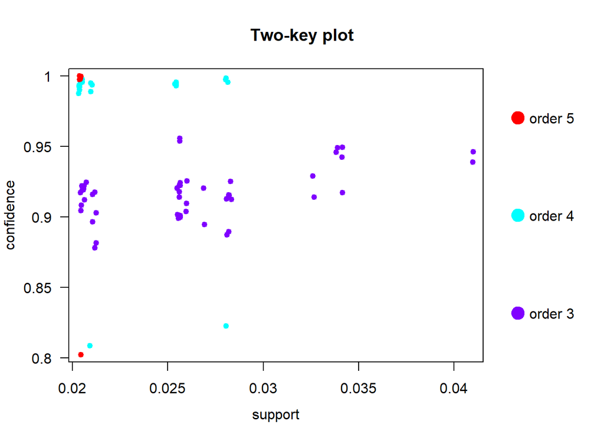

```r
plot(rules.ap, method = "two-key plot")
```

From this representation we observe that simpler rules usually present a larger support and lower confidence (it is easy to have cases where they are not fulfilled) than more complex rules, but the later ones shows higher confidence as well as lower support.

Finally, we can make a graph-based representation, where items and rules are represented as vertices connecting them with directed edges, for a small subset of the 10 rules with the highest lift.

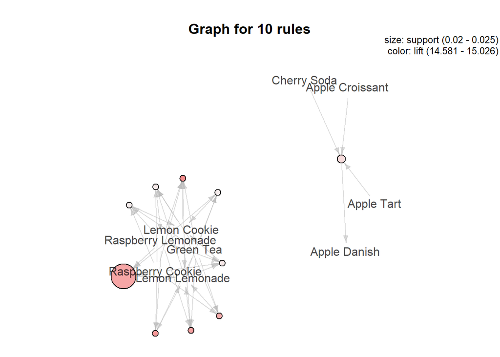

```r
subrules <- head(rules.ap, n = 10, by = "lift")
plot(subrules, method = "graph")
```

Despite of having represented only the 10 rules with highest lift, we can observe the formation of two clusters of items that are commonly purchased together. This fact was noted before and thus we can observe a pretty representation of the relation among the items with highest lift.

#### Association Rules using ECLAT

Using the frequent itemsets provided by the function “eclat()” we can determine the positive association rules using the command “ruleInduction()”.

```r
## Coerce tidLists to list.
as(tidLists(frequentItems), "list")
```

Now we look for the rules presenting a confidence higher than 0.8 and remove the redundant ones.

```r
rules.ec <- ruleInduction(frequentItems, confidence = 0.8)
#Remove redundant rules
rules.ec <- rules.ec[!is.redundant(rules.ec)]
summary(rules.ec)
```

```
## set of 81 rules
##
## rule length distribution (lhs + rhs):sizes
##  3  4  5
## 52 24  5
##
##    Min. 1st Qu.  Median    Mean 3rd Qu.    Max.
##    3.00    3.00    3.00    3.42    4.00    5.00
##
## summary of quality measures:
##     support          confidence          lift
##  Min.   :0.02040   Min.   :0.8016   Min.   : 7.942
##  1st Qu.:0.02055   1st Qu.:0.9128   1st Qu.:12.533
##  Median :0.02545   Median :0.9225   Median :13.407
##  Mean   :0.02471   Mean   :0.9380   Mean   :13.015
##  3rd Qu.:0.02810   3rd Qu.:0.9927   3rd Qu.:14.294
##  Max.   :0.04100   Max.   :1.0000   Max.   :15.026
```

We observe that we get the 81 rules, the same which we obtained with the APRIORI algorithm as expected.

#### Negative Association Rules

We focus now in detecting asssociation rules which take into account items that are part of the domain but that are not together part of a transaction, also known as **negative rules**. For that purpose we use the already defined function negative.rules(). As it is a really computationally expensive task we will only focus on finding rules associated to items which produce a higher income, particularly “Truffle Cake” and “Opera Cake”.

```r
itemList <- c("Truffle Cake ", "Opera Cake ")

neg.rules <- negative.rules(transactions.obj, rules.ap, itemList, min_support=0.02, min_confidence=0.8, minlen=2, maxlen=10, target="rules")
```

```
## Apriori
##
## Parameter specification:
##  confidence minval smax arem  aval originalSupport maxtime support minlen
##         0.8    0.1    1 none FALSE            TRUE       5    0.02      2
##  maxlen target   ext
##      10  rules FALSE
##
## Algorithmic control:
##  filter tree heap memopt load sort verbose
##     0.1 TRUE TRUE  FALSE TRUE    2    TRUE
##
## Absolute minimum support count: 400
##
## set item appearances ...[0 item(s)] done [0.00s].
## set transactions ...[52 item(s), 20000 transaction(s)] done [0.01s].
## sorting and recoding items ... [52 item(s)] done [0.00s].
## creating transaction tree ... done [0.01s].
## checking subsets of size 1 2 3 4 5 6 7 done [0.01s].
## writing ... [795 rule(s)] done [0.00s].
## creating S4 object  ... done [0.00s].
```

```r
neg.rules.lift <- sort (neg.rules, by="lift", decreasing=TRUE)
inspect(head(neg.rules.lift))
```

```
##     lhs                      rhs                support confidence     lift count
## [1] {Lemon Cookie ,
##      Raspberry Cookie ,
##      Raspberry Lemonade ,
##      !Opera Cake }        => {Lemon Lemonade }  0.02520  0.9960474 14.96690   504
## [2] {Apple Croissant ,
##      Apple Tart ,
##      Cherry Soda ,
##      !Opera Cake }        => {Apple Danish }    0.02075  0.9952038 14.73285   415
## [3] {Raspberry Cookie ,
##      Raspberry Lemonade ,
##      !Truffle Cake ,
##      !Opera Cake }        => {Lemon Lemonade }  0.02530  0.9370370 14.08020   506
## [4] {Apple Danish ,
##      Apple Tart ,
##      Cherry Soda ,
##      !Opera Cake }        => {Apple Croissant } 0.02075  0.9975962 14.05065   415
## [5] {Lemon Lemonade ,
##      Raspberry Lemonade ,
##      !Truffle Cake }      => {Lemon Cookie }    0.02550  0.9568480 14.01975   510
## [6] {Raspberry Cookie ,
##      Raspberry Lemonade ,
##      !Opera Cake }        => {Lemon Lemonade }  0.02540  0.9321101 14.00616   508
```

- Lemon Cookie, Raspberry Cookie, Raspberry Lemonade, !Opera Cake -> Lemon Lemonade
- Raspberry Cookie, Raspberry Lemonade, !Truffle Cake, !Opera Cake -> Lemon Lemonade

To conclude we represent the “negative” association rules in a scatter plot.

```
## To reduce overplotting, jitter is added! Use jitter = 0 to prevent jitter.
```

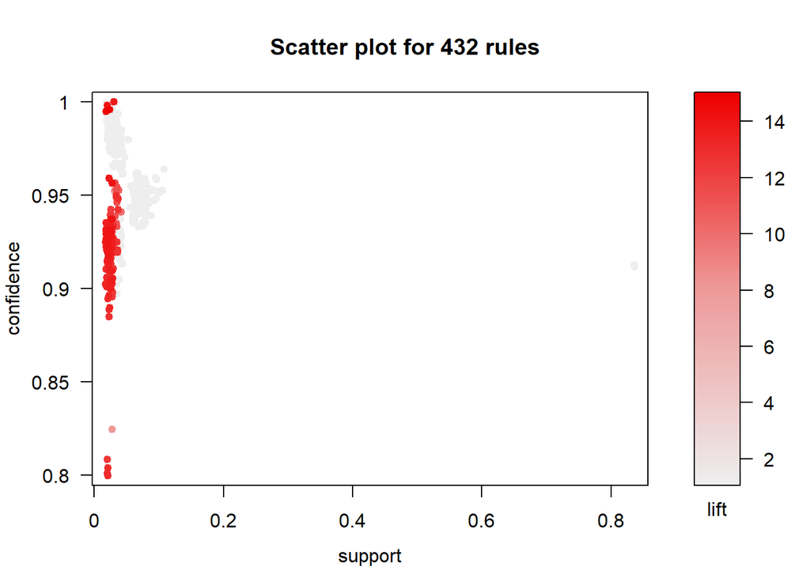

```r
plot(neg.rules)
```

As in the case of the 5,000 receipt database, we can observe that negative rules with a large support also present a low lift (a lift of nearly 1 means that this rules are providing no extra information with respect to random appearance), and that really high confidence rules also show a low support.

#### Analysis of most sold product

```r
rules1 <- apriori (data=transactions.obj, parameter=list (supp=0.01, conf = 0.5,minlen=2), appearance = list (default="lhs",rhs="Coffee Eclair "), control = list (verbose=F)) # get rules that lead to buying 'Truffle Cake'
rules1_conf <- sort (rules1, by="confidence", decreasing=TRUE) # 'high-confidence' rules.
inspect(head(rules1_conf))
```

```
##     lhs                   rhs              support confidence     lift count
## [1] {Almond Twist ,
##      Apple Pie ,
##      Hot Coffee }      => {Coffee Eclair } 0.02810  0.9946903 9.054986   562
## [2] {Almond Twist ,
##      Apple Pie }       => {Coffee Eclair } 0.03415  0.9499305 8.647524   683
## [3] {Apple Pie ,
##      Hot Coffee }      => {Coffee Eclair } 0.02820  0.9141005 8.321352   564
## [4] {Almond Twist ,
##      Hot Coffee }      => {Coffee Eclair } 0.02815  0.9124797 8.306598   563
## [5] {Blackberry Tart ,
##      Single Espresso } => {Coffee Eclair } 0.02695  0.8938640 8.137133   539
## [6] {Apple Pie }       => {Coffee Eclair } 0.03725  0.5023601 4.573146   745
```

### d) 75,000 Receipts

#### Exploring the data set

In the first place, we load the data set using the transactions.object() function

```r
dataset = transactions.object("75000/75000i.csv")
transactions.obj <- dataset$transactions.obj
```

Let’s get a little bit of insight on the data set by presenting some statistical information about the transaction object.

```r
summary(transactions.obj)
```

```
## transactions as itemMatrix in sparse format with
##  75000 rows (elements/itemsets/transactions) and
##  50 columns (items) and a density of 0.07098907
##
## most frequent items:
##   Coffee Eclair       Hot Coffee     Tuile Cookie      Cherry Tart
##             8193             7700             7556             6987
## Strawberry Cake           (Other)
##             6948           228825
##
## element (itemset/transaction) length distribution:
## sizes
##     1     2     3     4     5     6     7     8
##  3592 13579 24674 17003  8640  3840  2191  1481
##
##    Min. 1st Qu.  Median    Mean 3rd Qu.    Max.
##   1.000   3.000   3.000   3.549   4.000   8.000
##
## includes extended item information - examples:
##              labels
## 1 Almond Bear Claw
## 2 Almond Croissant
## 3      Almond Tart
##
## includes extended transaction information - examples:
##   transactionID
## 1             1
## 2             2
## 3             3
```

We can observe that again the data set is quite sparse presenting a density of 7.099%, that again “Coffee Eclair” is the most sold item and that the average sale consist of 3.549 items.

Now, we can represent in a histogram the 20 most frequent items.

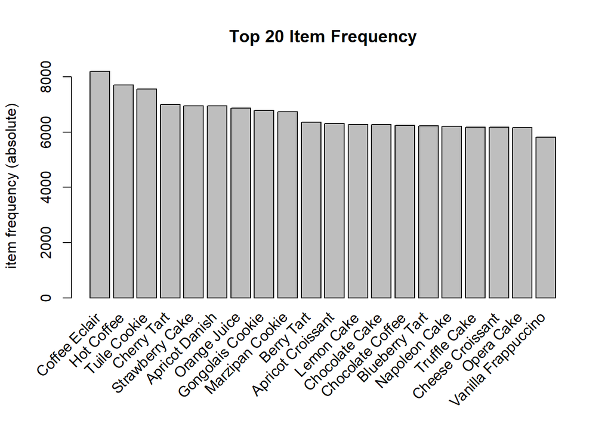

```r
itemFrequencyPlot(transactions.obj, topN=20, type="absolute", main="Top 20 Item Frequency")
```

From this representation we observe that there are 3 items that are clearly top in sales: “Coffee Eclair”, “Hot Coffee” and “Tuile Cookie”.

#### Most frequent itemsets

As we did with the 1000 items dataset, we are going to look for frequent itemsets using the “eclat()” function with a mininum support of 0.02 .

```r
frequentItems <- eclat(transactions.obj, parameter = list(support = 0.02, tidLists = TRUE))
```

```r
##Show the Frequent itemsets and respectives supports
inspect(frequentItems)
```

```
##       items                     support count
## [1]   {Apple Croissant ,
##        Apple Danish ,
##        Apple Tart ,
##        Cherry Soda }         0.02058667  1544
## [2]   {Apple Croissant ,
##        Apple Tart ,
##        Cherry Soda }         0.02077333  1558
## [3]   {Apple Croissant ,
##        Apple Danish ,
##        Cherry Soda }         0.02080000  1560
## [4]   {Apple Danish ,
##        Apple Tart ,
##        Cherry Soda }         0.02073333  1555
## [5]   {Apple Tart ,
##        Cherry Soda }         0.02278667  1709
## [6]   {Apple Danish ,
##        Cherry Soda }         0.02313333  1735
## [7]   {Apple Croissant ,
##        Cherry Soda }         0.02289333  1717
## [8]   {Chocolate Tart ,
##        Vanilla Frappuccino ,
##        Walnut Cookie }       0.02676000  2007
## [9]   {Vanilla Frappuccino ,
##        Walnut Cookie }       0.02848000  2136
## [10]  {Chocolate Tart ,
##        Walnut Cookie }       0.02856000  2142
## [11]  {Blackberry Tart ,
##        Coffee Eclair ,
##        Single Espresso }     0.02720000  2040
## [12]  {Coffee Eclair ,
##        Single Espresso }     0.02949333  2212
## [13]  {Blackberry Tart ,
##        Single Espresso }     0.02946667  2210
## [14]  {Green Tea ,
##        Lemon Cookie ,
##        Lemon Lemonade ,
##        Raspberry Cookie ,
##        Raspberry Lemonade }  0.02073333  1555
## [15]  {Green Tea ,
```

[output cut: 184 more lines]

```
## [110] {Single Espresso }     0.06797333  5098
## [111] {Walnut Cookie }       0.06785333  5089
## [112] {Cherry Soda }         0.06198667  4649
## [113] {Blueberry Danish }    0.04409333  3307
## [114] {Pecan Tart }          0.04337333  3253
## [115] {Ganache Cookie }      0.04324000  3243
## [116] {Almond Bear Claw }    0.04244000  3183
## [117] {Chocolate Croissant } 0.04324000  3243
## [118] {Apricot Tart }        0.04236000  3177
## [119] {Chocolate Eclair }    0.04237333  3178
## [120] {Almond Croissant }    0.04273333  3205
## [121] {Vanilla Eclair }      0.04252000  3189
## [122] {Vanilla Meringue }    0.04238667  3179
## [123] {Almond Tart }         0.04204000  3153
## [124] {Chocolate Meringue }  0.04193333  3145
```

Let’s summarize all these frequent itemsets.

```r
summary(frequentItems)
```

```
## set of 124 itemsets
##
## most frequent items:
##          Green Tea        Lemon Cookie      Lemon Lemonade    Raspberry Cookie
##                  16                  16                  16                  16
## Raspberry Lemonade              (Other)
##                  16                 158
##
## element (itemset/transaction) length distribution:sizes
##  1  2  3  4  5
## 50 43 23  7  1
##
##    Min. 1st Qu.  Median    Mean 3rd Qu.    Max.
##   1.000   1.000   2.000   1.919   2.250   5.000
##
## summary of quality measures:
##     support            count
##  Min.   :0.02059   Min.   :1544
##  1st Qu.:0.02779   1st Qu.:2084
##  Median :0.03719   Median :2790
##  Mean   :0.04638   Mean   :3479
##  3rd Qu.:0.06788   3rd Qu.:5091
##  Max.   :0.10924   Max.   :8193
##
## includes transaction ID lists: TRUE
##
## mining info:
##              data ntransactions support
##  transactions.obj         75000    0.02
```

#### Association Rules using APRIORI

We aim now to find rules using the APRIORI algorithm. We are going to look for rules with a minimum support of 0.02 and a minimum confidence of 0.8.

```r
#We require minlen 2 to avoid having rules with only 1 consequent and 0 antecedent
rules.ap <- apriori(transactions.obj, parameter = list(supp = 0.02, conf = 0.8, minlen=2))
```

```
## Apriori
##
## Parameter specification:
##  confidence minval smax arem  aval originalSupport maxtime support minlen
##         0.8    0.1    1 none FALSE            TRUE       5    0.02      2
##  maxlen target   ext
##      10  rules FALSE
##
## Algorithmic control:
##  filter tree heap memopt load sort verbose
##     0.1 TRUE TRUE  FALSE TRUE    2    TRUE
##
## Absolute minimum support count: 1500
##
## set item appearances ...[0 item(s)] done [0.00s].
## set transactions ...[50 item(s), 75000 transaction(s)] done [0.02s].
## sorting and recoding items ... [50 item(s)] done [0.00s].
## creating transaction tree ... done [0.04s].
## checking subsets of size 1 2 3 4 5 done [0.01s].
## writing ... [85 rule(s)] done [0.00s].
## creating S4 object  ... done [0.01s].
```

We have obtained 85 rules, however some of them provide no extra information related to others. These are called **redudant rules** and we can find them automatically.

```r
inspect(rules.ap[is.redundant(rules.ap)])
```

We observe that there are no redudant rules. Let’s get now some statistical information on the rules.

```r
summary(rules.ap)
```

```
## set of 85 rules
##
## rule length distribution (lhs + rhs):sizes
##  3  4  5
## 52 28  5
##
##    Min. 1st Qu.  Median    Mean 3rd Qu.    Max.
##   3.000   3.000   3.000   3.447   4.000   5.000
##
## summary of quality measures:
##     support          confidence          lift            count
##  Min.   :0.02059   Min.   :0.8049   Min.   : 7.924   Min.   :1544
##  1st Qu.:0.02073   1st Qu.:0.9070   1st Qu.:12.873   1st Qu.:1555
##  Median :0.02093   Median :0.9229   Median :13.403   Median :1570
##  Mean   :0.02454   Mean   :0.9319   Mean   :13.035   Mean   :1840
##  3rd Qu.:0.02676   3rd Qu.:0.9922   3rd Qu.:14.514   3rd Qu.:2007
##  Max.   :0.04111   Max.   :1.0000   Max.   :14.784   Max.   :3083
##
## mining info:
##              data ntransactions support confidence
##  transactions.obj         75000    0.02        0.8
```

We observe that all the rules present both large values of confidence, with a mean of 0.9319, and lift, with a mean of 13.035 . Also, we have rules with 3 items (52 cases), 4 items (28 cases) and 5 items (5 cases), being 3.447 items the average.

So, let’s now classify the rules by lift:

```r
#High lift rules
rules.lift <- sort (rules.ap, by="lift", decreasing=TRUE)
inspect(head(rules.lift)) # show the support, lift and confidence for higher lift rules
```

```
##     lhs                      rhs                      support confidence     lift count
## [1] {Green Tea ,
##      Lemon Cookie ,
##      Lemon Lemonade ,
##      Raspberry Lemonade } => {Raspberry Cookie }   0.02073333  1.0000000 14.78415  1555
## [2] {Green Tea ,
##      Lemon Cookie ,
##      Lemon Lemonade ,
##      Raspberry Cookie }   => {Raspberry Lemonade } 0.02073333  1.0000000 14.76087  1555
## [3] {Apple Danish ,
##      Apple Tart ,
##      Cherry Soda }        => {Apple Croissant }    0.02058667  0.9929260 14.75519  1544
## [4] {Green Tea ,
##      Lemon Lemonade ,
##      Raspberry Lemonade } => {Raspberry Cookie }   0.02074667  0.9974359 14.74624  1556
## [5] {Lemon Cookie ,
##      Lemon Lemonade ,
##      Raspberry Lemonade } => {Raspberry Cookie }   0.02556000  0.9973985 14.74569  1917
## [6] {Green Tea ,
##      Lemon Cookie ,
##      Raspberry Cookie }   => {Raspberry Lemonade } 0.02073333  0.9980745 14.73245  1555
```

Then, let’s classify the rules by confidence:

```r
#High confidence rules
rules.confidence <- sort (rules.ap, by="confidence", decreasing=TRUE)
inspect(head(rules.confidence)) # show the support, lift and confidence for high confidence rules
```

```
##     lhs                      rhs                      support confidence     lift count
## [1] {Green Tea ,
##      Lemon Cookie ,
##      Raspberry Cookie ,
##      Raspberry Lemonade } => {Lemon Lemonade }     0.02073333  1.0000000 14.65416  1555
## [2] {Green Tea ,
##      Lemon Cookie ,
##      Lemon Lemonade ,
##      Raspberry Cookie }   => {Raspberry Lemonade } 0.02073333  1.0000000 14.76087  1555
## [3] {Green Tea ,
##      Lemon Cookie ,
##      Lemon Lemonade ,
##      Raspberry Lemonade } => {Raspberry Cookie }   0.02073333  1.0000000 14.78415  1555
## [4] {Green Tea ,
##      Lemon Lemonade ,
##      Raspberry Cookie ,
##      Raspberry Lemonade } => {Lemon Cookie }       0.02073333  0.9993573 14.69355  1555
## [5] {Green Tea ,
##      Lemon Cookie ,
##      Raspberry Cookie }   => {Raspberry Lemonade } 0.02073333  0.9980745 14.73245  1555
## [6] {Green Tea ,
##      Lemon Cookie ,
##      Raspberry Cookie }   => {Lemon Lemonade }     0.02073333  0.9980745 14.62594  1555
```

The rules with a confidence of 1 mean that, whenever the LHS item was purchased, the RHS item was always purchased. We notice that lift and confidence give as more important rules those which are quite infrequent. Consequently, we will also classify the rules according to support:

```r
#High support rules
rules.support <- sort (rules.ap, by="support", decreasing=TRUE)

inspect(head(rules.support)) # show the support, lift and confidence for high support rules
```

```
##     lhs                                 rhs               support    confidence
## [1] {Apricot Danish ,Opera Cake }    => {Cherry Tart }    0.04110667 0.9553765
## [2] {Cherry Tart ,Opera Cake }       => {Apricot Danish } 0.04110667 0.9477405
## [3] {Almond Twist ,Apple Pie }       => {Coffee Eclair }  0.03432000 0.9356598
## [4] {Apple Pie ,Coffee Eclair }      => {Almond Twist }   0.03432000 0.9209302
## [5] {Almond Twist ,Coffee Eclair }   => {Apple Pie }      0.03432000 0.9245690
## [6] {Casino Cake ,Chocolate Coffee } => {Chocolate Cake } 0.03338667 0.9474082
##     lift      count
## [1] 10.255222 3083
## [2] 10.237727 3083
## [3]  8.565175 2574
## [4] 11.929148 2574
## [5] 11.988705 2574
## [6] 11.341679 2504
```

From the rules found we can highlight the following:

1. Rules with the highest lift (over 14) also present values of confidence near 1, however their support is quite low (around 0.02). Also notice that nearly all of them are combinations from a reduced number of items. This will become more clear when we use the graph representation for this rules.
2. We have rules with confidence slightly lower than 1 and a large lift (over 10) and a large support of nearly 0.04, particularly they are the same as in the case of the 20,000 receipt database:
- Cherry Tart, Opera Cake -> Apricot Danish
- Apricot Danish, Opera Cake -> Cherry Tart

  Notice that these rules might be the most interesting ones as the occur much more frequently than the above mentioned while keeping large values of lift and confidence.

#### Rules visualization

We are going to use different visualization techniques implemented in the library “arulesViz”.

Firstly, we are using a scatter plot using support and confidence on the axes, and lift as the color value.

```
## To reduce overplotting, jitter is added! Use jitter = 0 to prevent jitter.
```

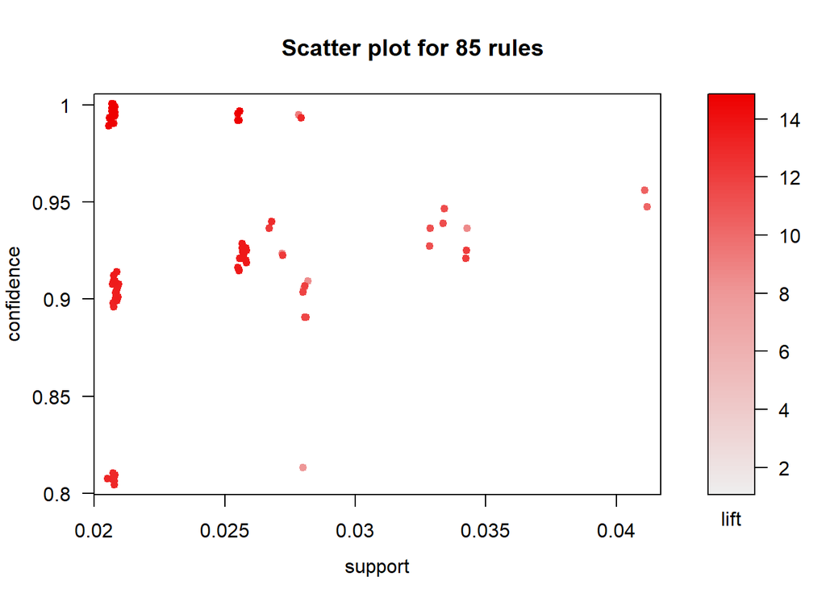

```r
plot(rules.ap)
```

The most interesting rules which we present above reside on the large support/confidence regions. Also notice that the vast majority of rules present large values of confidence (over 0.9). It is quite fascinating to observe the formation of clusters of rules, which are consituted by closed itemsets of items forming new rules from permutations of themselves.

We can also visualize a two-key plot with support and confidence for the x and y-axes and the color of the points representing the number of items in the rule.

```
## To reduce overplotting, jitter is added! Use jitter = 0 to prevent jitter.
```

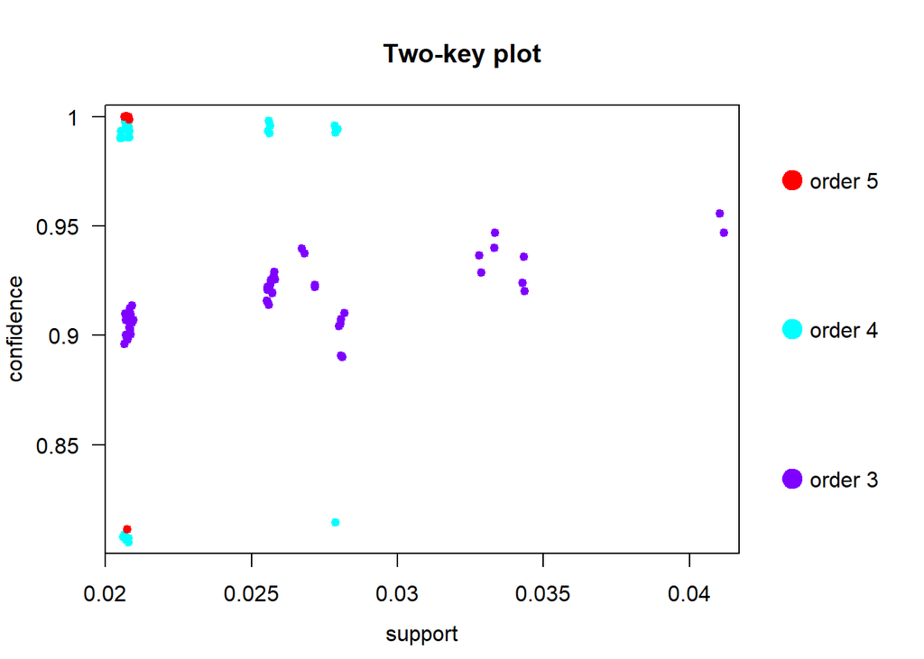

```r
plot(rules.ap, method = "two-key plot")
```

From this representation we observe that simpler rules usually present a larger support than more complex rules, but the later ones shows higher confidence.

Finally, we can make a graph-based representation, where items and rules are represented as vertices connecting them with directed edges, for a small subset of the 10 rules with the highest lift.

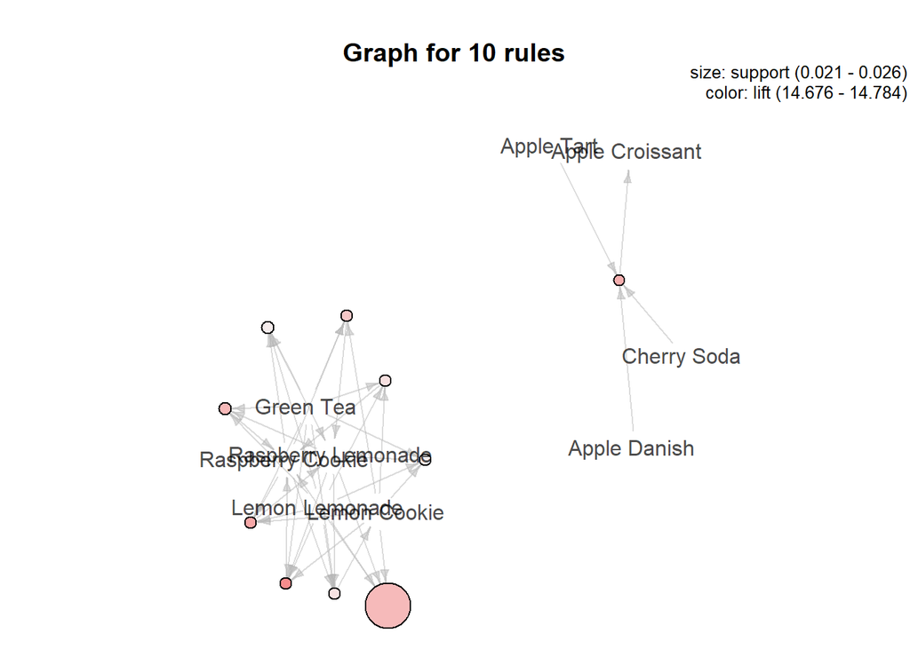

```r
subrules <- head(rules.ap, n = 10, by = "lift")
plot(subrules, method = "graph")
```

Despite of having represented only the 10 rules with highest lift, we can observe the formation of two clusters of items that are commonly purchased together. This fact was noted before and thus we can observe a pretty representation of the relation among the items with highest lift.

#### Association Rules using ECLAT

Using the frequent itemsets provided by the function “eclat()” we can determine the positive association rules using the command “ruleInduction()”.

```r
## Coerce tidLists to list.
as(tidLists(frequentItems), "list")
```

Now we look for the rules presenting a confidence higher than 0.8 and remove the redundant ones.

```r
rules.ec <- ruleInduction(frequentItems, confidence = 0.8)
#Remove redundant rules
rules.ec <- rules.ec[!is.redundant(rules.ec)]
summary(rules.ec)
```

```
## set of 85 rules
##
## rule length distribution (lhs + rhs):sizes
##  3  4  5
## 52 28  5
##
##    Min. 1st Qu.  Median    Mean 3rd Qu.    Max.
##   3.000   3.000   3.000   3.447   4.000   5.000
##
## summary of quality measures:
##     support          confidence          lift
##  Min.   :0.02059   Min.   :0.8049   Min.   : 7.924
##  1st Qu.:0.02073   1st Qu.:0.9070   1st Qu.:12.873
##  Median :0.02093   Median :0.9229   Median :13.403
##  Mean   :0.02454   Mean   :0.9319   Mean   :13.035
##  3rd Qu.:0.02676   3rd Qu.:0.9922   3rd Qu.:14.514
##  Max.   :0.04111   Max.   :1.0000   Max.   :14.784
```

We observe that we get the 85 rules, the same which we obtained with the APRIORI algorithm as expected.

#### Negative Association Rules

We focus now in detecting asssociation rules which take into account items that are part of the domain but that are not together part of a transaction, also known as **negative rules**. For that purpose we use the already defined function negative.rules(). As it is a really computationally expensive task we will only focus on finding rules associated to items which produce a higher income, particularly “Truffle Cake” and “Opera Cake”.

```r
itemList <- c("Truffle Cake ", "Opera Cake ")

neg.rules <- negative.rules(transactions.obj, rules.ap, itemList, min_support=0.02, min_confidence=0.8, minlen=2, maxlen=10, target="rules")
```

```
## Apriori
##
## Parameter specification:
##  confidence minval smax arem  aval originalSupport maxtime support minlen
##         0.8    0.1    1 none FALSE            TRUE       5    0.02      2
##  maxlen target   ext
##      10  rules FALSE
##
## Algorithmic control:
##  filter tree heap memopt load sort verbose
##     0.1 TRUE TRUE  FALSE TRUE    2    TRUE
##
## Absolute minimum support count: 1500
##
## set item appearances ...[0 item(s)] done [0.00s].
## set transactions ...[52 item(s), 75000 transaction(s)] done [0.03s].
## sorting and recoding items ... [52 item(s)] done [0.00s].
## creating transaction tree ... done [0.04s].
## checking subsets of size 1 2 3 4 5 6 7 done [0.02s].
## writing ... [807 rule(s)] done [0.00s].
## creating S4 object  ... done [0.01s].
```

```r
neg.rules.lift <- sort (neg.rules, by="lift", decreasing=TRUE)
inspect(head(neg.rules.lift))
```

```
##     lhs                      rhs                      support confidence     lift count
## [1] {Apple Danish ,
##      Apple Tart ,
##      Cherry Soda ,
##      !Opera Cake }        => {Apple Croissant }    0.02042667  0.9941596 14.77352  1532
## [2] {Lemon Cookie ,
##      Lemon Lemonade ,
##      Raspberry Lemonade ,
##      !Truffle Cake ,
##      !Opera Cake }        => {Raspberry Cookie }   0.02530667  0.9984219 14.76082  1898
## [3] {Lemon Cookie ,
##      Lemon Lemonade ,
##      Raspberry Lemonade ,
##      !Opera Cake }        => {Raspberry Cookie }   0.02550667  0.9979134 14.75330  1913
## [4] {Lemon Cookie ,
##      Lemon Lemonade ,
##      Raspberry Lemonade ,
##      !Truffle Cake }      => {Raspberry Cookie }   0.02536000  0.9979014 14.75312  1902
## [5] {Green Tea ,
##      Lemon Cookie ,
##      Raspberry Cookie ,
##      !Truffle Cake }      => {Raspberry Lemonade } 0.02058667  0.9987063 14.74178  1544
## [6] {Green Tea ,
##      Lemon Cookie ,
##      Lemon Lemonade ,
##      !Truffle Cake ,
##      !Opera Cake }        => {Raspberry Cookie }   0.02056000  0.9954810 14.71734  1542
```

Notice that some important rules in the sense of lift appear when considering “negative” association rules. As was the case with positive association rules, we have some interesting rules with a large lift (over 14) and high confidence (over 0.99) while presenting a not insignificant support of about 0.025 like the followings:

- Lemon Cookie, Lemon Lemonade, Raspberry Lemonade, !Truffle Cake -> Raspberry Cookie
- Lemon Cookie, Lemon Lemonade, Raspberry Lemonade, !Opera Cake -> Raspberry Cookie
- Lemon Cookie, Lemon Lemonade, Raspberry Lemonade, !Truffle Cake, !Opera Cake -> Raspberry Cookie

To conclude we represent the “negative” association rules in a scatter plot.

```
## To reduce overplotting, jitter is added! Use jitter = 0 to prevent jitter.
```

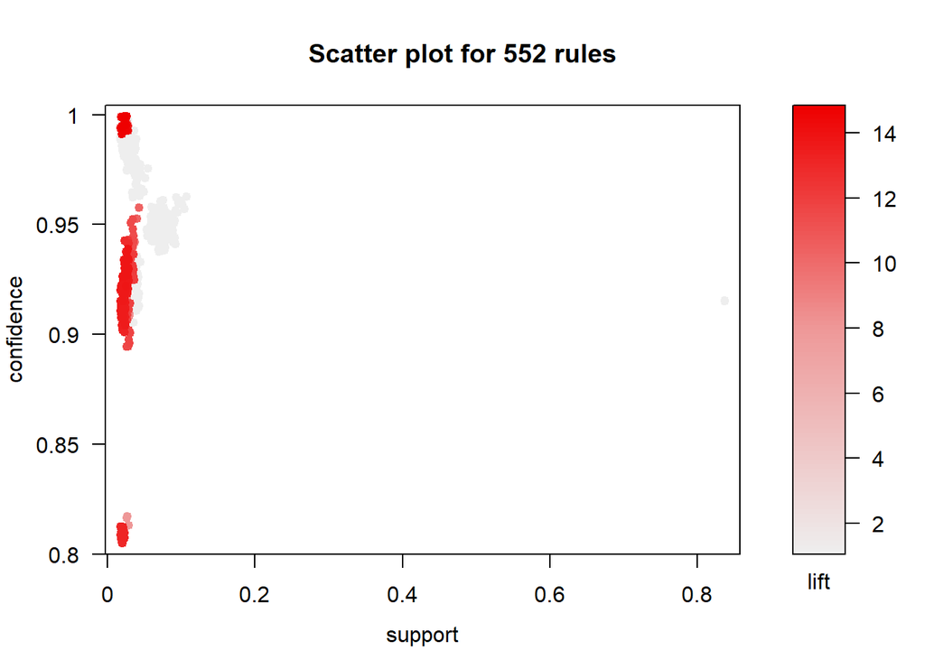

```r
plot(neg.rules)
```

As in the case of the rules from the previous data sets, we can observe that rules with a large support also present a low lift (a lift of nearly 1 means that this rules are providing no extra information with respect to random appearance), and that really high confidence rules also show a low support.

#### Analysis of most sold product

Finally, suppose that our company whats to make “Hot Coffee” the star product of the brand and compete with Starbucks. Then, it might be fruitful to study what customers had bought before buying “Hot Coffee”, which actually is the second item with more sales. For that purpose we can make an analysis to better understand the patterns that led to the purchase of “Hot Coffee” by looking for rules with “Hot Coffee” in the RHS.

```r
rules1 <- apriori (data=transactions.obj, parameter=list (supp=0.01, conf = 0.5,minlen=2), appearance = list (default="lhs",rhs="Hot Coffee "), control = list (verbose=F)) # get rules that lead to buying 'Truffle Cake'
rules1_conf <- sort (rules1, by="confidence", decreasing=TRUE) # 'high-confidence' rules.
inspect(head(rules1_conf))
```

```
##     lhs                     rhs              support confidence     lift count
## [1] {Almond Twist ,
##      Apple Pie ,
##      Coffee Eclair }     => {Hot Coffee } 0.02792000  0.8135198 7.923894  2094
## [2] {Almond Twist ,
##      Apple Pie }         => {Hot Coffee } 0.02805333  0.7648128 7.449475  2104
## [3] {Almond Twist ,
##      Coffee Eclair }     => {Hot Coffee } 0.02812000  0.7575431 7.378667  2109
## [4] {Apricot Croissant ,
##      Blueberry Tart }    => {Hot Coffee } 0.03282667  0.7545204 7.349224  2462
## [5] {Apple Pie ,
##      Coffee Eclair }     => {Hot Coffee } 0.02809333  0.7538462 7.342657  2107
```

We conclude that a promotion campaign of a pack of “Almond Twist”, “Apple Pie” and “Coffee Eclair” may result in an increase of the “Hot Coffee” sales, which can result in remarkable profits for the company.

# Exercise 2.

**Brief outline**. Features are computed from a digitized image of a fine needle aspirate (FNA) of a breast mass. They describe characteristics of the cell nuclei present in the image. The 3-dimensional space is that described in: [*K. P. Bennett and O. L. Mangasarian: Robust Linear Programming Discrimination of Two Linearly Inseparable Sets", Optimization Methods and Software 1, 1992, 23-34*]. Perform anomaly detection analysis using the “Breast Cancer Wisconsin (Diagnostic) Data Set” from [UCI machine learning repository](http://archive.ics.uci.edu/ml/datasets.php).

Eliminate the class label and detect anomalies using a) DBSCAN, b) Expectation Maximization, c) Local Outler Factor (LOF). If the following convention is used for the class labels: M = malignant is an outlier, B = benign is normal, what can you say about the results you obtained? Which method is “best”?

## Solution

First of all, we load the required libraries to perform the association mining techniques.

```r
library(ggplot2)
library(data.table)
```

In this particular problem we have a dataset called *breast-cancer-wisconsin.data* and the information about it is stored in the file *breast-cancer-wisconsin.names*. Let’s load the dataset and take a look at it:

```r
dataset <- read.table("breast-cancer-wisconsin.data", sep=",")
str(dataset)
```

```
## 'data.frame':    699 obs. of  11 variables:
##  $ V1 : int  1000025 1002945 1015425 1016277 1017023 1017122 1018099 1018561 1033078 1033078 ...
##  $ V2 : int  5 5 3 6 4 8 1 2 2 4 ...
##  $ V3 : int  1 4 1 8 1 10 1 1 1 2 ...
##  $ V4 : int  1 4 1 8 1 10 1 2 1 1 ...
##  $ V5 : int  1 5 1 1 3 8 1 1 1 1 ...
##  $ V6 : int  2 7 2 3 2 7 2 2 2 2 ...
##  $ V7 : Factor w/ 11 levels "?","1","10","2",..: 2 3 4 6 2 3 3 2 2 2 ...
##  $ V8 : int  3 3 3 3 3 9 3 3 1 2 ...
##  $ V9 : int  1 2 1 7 1 7 1 1 1 1 ...
##  $ V10: int  1 1 1 1 1 1 1 1 5 1 ...
##  $ V11: int  2 2 2 2 2 4 2 2 2 2 ...
```

```r
summary(dataset)
```

```
##        V1                 V2               V3               V4
##  Min.   :   61634   Min.   : 1.000   Min.   : 1.000   Min.   : 1.000
##  1st Qu.:  870688   1st Qu.: 2.000   1st Qu.: 1.000   1st Qu.: 1.000
##  Median : 1171710   Median : 4.000   Median : 1.000   Median : 1.000
##  Mean   : 1071704   Mean   : 4.418   Mean   : 3.134   Mean   : 3.207
##  3rd Qu.: 1238298   3rd Qu.: 6.000   3rd Qu.: 5.000   3rd Qu.: 5.000
##  Max.   :13454352   Max.   :10.000   Max.   :10.000   Max.   :10.000
##
##        V5               V6               V7            V8
##  Min.   : 1.000   Min.   : 1.000   1      :402   Min.   : 1.000
##  1st Qu.: 1.000   1st Qu.: 2.000   10     :132   1st Qu.: 2.000
##  Median : 1.000   Median : 2.000   2      : 30   Median : 3.000
##  Mean   : 2.807   Mean   : 3.216   5      : 30   Mean   : 3.438
##  3rd Qu.: 4.000   3rd Qu.: 4.000   3      : 28   3rd Qu.: 5.000
##  Max.   :10.000   Max.   :10.000   8      : 21   Max.   :10.000
##                                    (Other): 56
##        V9              V10              V11
##  Min.   : 1.000   Min.   : 1.000   Min.   :2.00
##  1st Qu.: 1.000   1st Qu.: 1.000   1st Qu.:2.00
##  Median : 1.000   Median : 1.000   Median :2.00
##  Mean   : 2.867   Mean   : 1.589   Mean   :2.69
##  3rd Qu.: 4.000   3rd Qu.: 1.000   3rd Qu.:4.00
##  Max.   :10.000   Max.   :10.000   Max.   :4.00
##
```

```r
head(dataset)
```

```
##        V1 V2 V3 V4 V5 V6 V7 V8 V9 V10 V11
## 1 1000025  5  1  1  1  2  1  3  1   1   2
## 2 1002945  5  4  4  5  7 10  3  2   1   2
## 3 1015425  3  1  1  1  2  2  3  1   1   2
## 4 1016277  6  8  8  1  3  4  3  7   1   2
## 5 1017023  4  1  1  3  2  1  3  1   1   2
## 6 1017122  8 10 10  8  7 10  9  7   1   4
```

We observe that our dataset has 699 observations, each of them represented in a row, and 11 different attributes. According to the information in *breast-cancer-wisconsin.names*, the 11 features correspond to:

| Variable name | Feature | Value |
| --- | --- | --- |
| v1 | Sample code number | id number |
| v2 | Clump Thickness | 1 - 10 |
| v3 | Uniformity of Cell Size | 1 - 10 |
| v4 | Uniformity of Cell Shape | 1 - 10 |
| v5 | Marginal Adhesion | 1 - 10 |
| v6 | Single Epithelial Cell Size | 1 - 10 |
| v7 | Bare Nuclei | 1 - 10 |
| v8 | Bland Chromatin | 1 - 10 |
| v9 | Normal Nucleoli | 1 - 10 |
| v10 | Mitoses | 1 - 10 |
| v11 | Class: | (2 for benign, 4 for malignant) |

From the information file *breast-cancer-wisconsin.names* we also discover that:

- There are 16 instances that contain a single missing attribute value denoted by ‘?’ (all of them related to ‘v7’ -bare nuclei).

```r
cat('Number of missing features: ', sum(dataset=='?'))
```

```
## Number of missing features:  16
```

- The dataset is unbalanced, presenting a distribution of the classes as follows:
  - Benign: 458 (65.5%)
  - Malignant: 241 (34.5%)

```r
cat('Number of benign cases: ', sum(dataset$V11==2))
```

```
## Number of benign cases:  458
```

```r
cat('Number of malignant cases: ', sum(dataset$V11==4))
```

```
## Number of malignant cases:  241
```

We now remove the class label and the sample code number. We also observe that variable “v7” is of class factor instead of numeric and that it contains the 16 NA’s values. Probably this happens because the test require to determine bare nuclei was not done, so we will forego this attribute.

```r
class <- dataset$V11 #save classes column
class[class==2] = 1 #benign
class[class==4] = 0 #malignant
patient_id <- dataset$V1

dataset$V11 <- NULL #remove classes column
dataset$V1 <- NULL #remove id number column
dataset$V7 <- NULL #remove this column because it has missing data
#dataset$V7 <- as.numeric(as.character(dataset$V7)) #convert from factor to numeric variable "v7"
```

We will now use principal component analysis to create a two-dimensional mapping for data visualization. To achieve that, it is recomendable to perform first a scaling of the data:

```r
dataset.scaled <- scale(dataset)
summary(dataset.scaled)
```

```
##        V2                V3                V4                V5
##  Min.   :-1.2138   Min.   :-0.6995   Min.   :-0.7428   Min.   :-0.6328
##  1st Qu.:-0.8587   1st Qu.:-0.6995   1st Qu.:-0.7428   1st Qu.:-0.6328
##  Median :-0.1484   Median :-0.6995   Median :-0.7428   Median :-0.6328
##  Mean   : 0.0000   Mean   : 0.0000   Mean   : 0.0000   Mean   : 0.0000
##  3rd Qu.: 0.5619   3rd Qu.: 0.6114   3rd Qu.: 0.6032   3rd Qu.: 0.4179
##  Max.   : 1.9825   Max.   : 2.2499   Max.   : 2.2856   Max.   : 2.5192
##        V6                V8                V9               V10
##  Min.   :-1.0008   Min.   :-0.9998   Min.   :-0.6114   Min.   :-0.3437
##  1st Qu.:-0.5492   1st Qu.:-0.5896   1st Qu.:-0.6114   1st Qu.:-0.3437
##  Median :-0.5492   Median :-0.1795   Median :-0.6114   Median :-0.3437
##  Mean   : 0.0000   Mean   : 0.0000   Mean   : 0.0000   Mean   : 0.0000
##  3rd Qu.: 0.3541   3rd Qu.: 0.6407   3rd Qu.: 0.3710   3rd Qu.:-0.3437
##  Max.   : 3.0637   Max.   : 2.6912   Max.   : 2.3359   Max.   : 4.9039
```

Next, in order to reduce dimensionality we perform principal component analysis over the 8 attributes we have:

```r
dataset.pca <- prcomp(dataset.scaled)
summary(dataset.pca)
```

```
## Importance of components:
##                           PC1     PC2     PC3     PC4     PC5     PC6     PC7
## Standard deviation     2.2975 0.86438 0.73405 0.63905 0.61290 0.54618 0.51251
## Proportion of Variance 0.6598 0.09339 0.06735 0.05105 0.04696 0.03729 0.03283
## Cumulative Proportion  0.6598 0.75322 0.82057 0.87162 0.91858 0.95586 0.98870
##                           PC8
## Standard deviation     0.3007
## Proportion of Variance 0.0113
## Cumulative Proportion  1.0000
```

We have obtained 8 principal components and we see that with PC1 and PC2 we can explain the 75% of the variance in the data. As an educated approach we will use these two components to represent the data and get some insight about its distribution:

```r
embedding <- data.table(dataset.pca$x[, 1:2])
embedding[, Patient_ID := patient_id]
embedding
```

```
##             PC1         PC2 Patient_ID
##   1:  1.3031545 -0.14855302    1000025
##   2: -0.9160961 -0.19060580    1002945
##   3:  1.5294509 -0.02905987    1015425
##   4: -1.5481522 -0.78457509    1016277
##   5:  1.1719109 -0.11651130    1017023
##  ---
## 695:  1.6657092  0.23978883     776715
## 696:  1.9411295  0.24746662     841769
## 697: -4.1077805 -0.74404564     888820
## 698: -2.3468848 -1.36372591     897471
## 699: -2.6648821 -1.38457326     897471
```

We now plot the several observations in the dataset according to the positionn of each observation in terms of PC1 and PC2 and we label them with their respective ID.

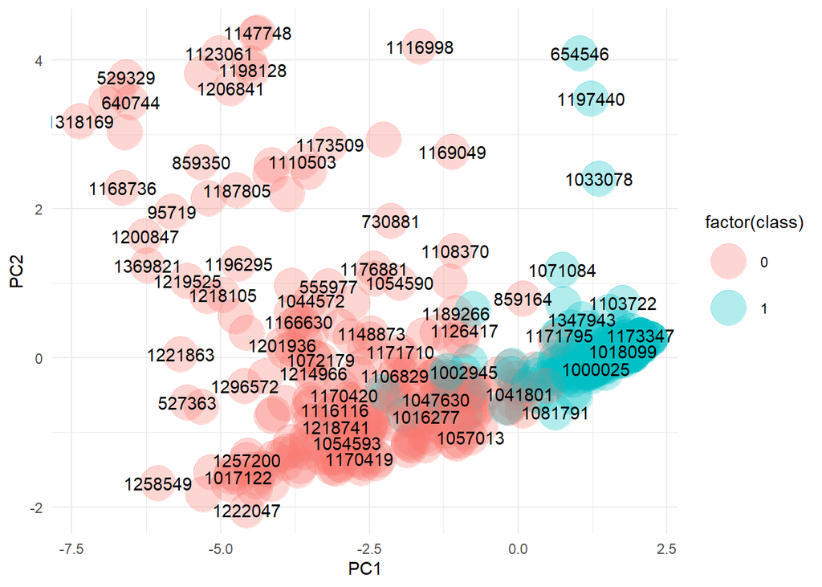

```r
g1 <- ggplot(embedding, aes(x = PC1, y = PC2)) +
    geom_point(aes(colour = factor(class)), size = 10, alpha = 0.3) +
    geom_text(aes(label = Patient_ID), check_overlap = TRUE) +
    theme_minimal()
g1
```

With this two-dimensional plot we can get an overall picture of the distribution of the data as well as identify candidates for being outliers.

We will now use three different algorithms to classify the observations of the dataset and compare them with the labels given.

### a) DBSCAN

Our goal is to determine now the outliers according to a machine learning method called DBSCAN algorithm.

```r
library(dbscan)
library(caret) #package required for calculating the confussion matrix
```

To use DBSCAN we require to define two parameters:

- **eps**: radius to search for neighbors around each point.
- **minPts**: minimum number of neighbouring points to classify the observation as a “core point”.

We will now try to classify the dataset observations as better as possible trying to improve the accuracy of the classifications. For that purpose we will go for trial and error and use the confussion matrix to get some insight of why the algorithm is misclassifying some observations.

```r
dbs.classification = dbscan(dataset.scaled, eps=1.48, minPts=100)
confusionMatrix(factor(dbs.classification$cluster), factor(class))
```

```
## Confusion Matrix and Statistics
##
##           Reference
## Prediction   0   1
##          0 232  20
##          1   9 438
##
##                Accuracy : 0.9585
##                  95% CI : (0.941, 0.972)
##     No Information Rate : 0.6552
##     P-Value [Acc > NIR] : < 2e-16
##
##                   Kappa : 0.9092
##
##  Mcnemar's Test P-Value : 0.06332
##
##             Sensitivity : 0.9627
##             Specificity : 0.9563
##          Pos Pred Value : 0.9206
##          Neg Pred Value : 0.9799
##              Prevalence : 0.3448
##          Detection Rate : 0.3319
##    Detection Prevalence : 0.3605
##       Balanced Accuracy : 0.9595
##
##        'Positive' Class : 0
##
```

We observe from the confussion matrix that our algorithm is classifying with an accuracy of 95.85%. Also, the sensitivity and the specificity present large values over 95%. These can be verified at the confussion matrix where we observe that we have both few false positives and false negatives.

At this point recall that benign examples are labelled with a ‘1’ and malignant with a ‘0’. Let’s represent the predicted classes with the DBSCAN algorithm.

```r
embedding[, DClusters := dbs.classification$cluster]
embedding
```

```
##             PC1         PC2 Patient_ID DClusters
##   1:  1.3031545 -0.14855302    1000025         1
##   2: -0.9160961 -0.19060580    1002945         0
##   3:  1.5294509 -0.02905987    1015425         1
##   4: -1.5481522 -0.78457509    1016277         0
##   5:  1.1719109 -0.11651130    1017023         1
##  ---
## 695:  1.6657092  0.23978883     776715         1
## 696:  1.9411295  0.24746662     841769         1
## 697: -4.1077805 -0.74404564     888820         0
## 698: -2.3468848 -1.36372591     897471         0
## 699: -2.6648821 -1.38457326     897471         0
```

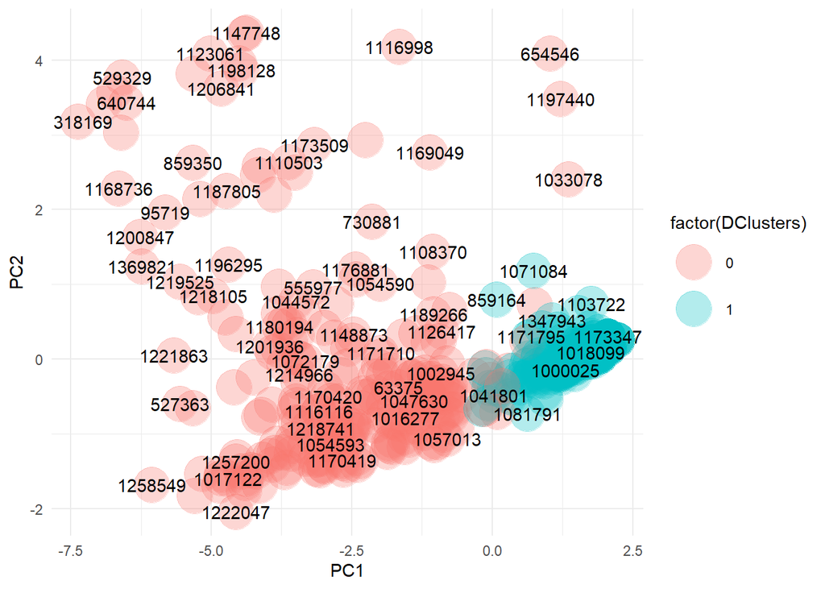

```r
ggplot(embedding, aes(x = PC1, y = PC2)) +
  geom_point(aes(colour = factor(DClusters)), size = 10, alpha = 0.3) +
  geom_text(aes(label = Patient_ID), check_overlap = TRUE) +
  theme_minimal()
```

From this representation we can see that the benign predictions (cluster 1) seem to be condensed in a small region, while malignant predictions (cluster 0) appear to be more scattered presenting both areas with high density and low density. Notice that, despite of being a two dimensional simplified representation, we can observe that DBSCAN struggles with zones where the density varies, consider for example the observation 1033078, which has been misclassified as anomaly.

### b) Expectation Maximization

We will now use an unsupervised clustering algorithm that tries to classify data into clusters according to a combination of gaussian distributions, based on their orientation and variance, called Expectation Maximization (EM).

```r
library(mclust)
```

As a first guess we will try to classify the observations into two gaussian distributions and see how good is the result we get:

```r
expec.max <- Mclust(dataset.scaled, G = 2)
```

Let’s evaluate the classification done using a confussion matrix

```r
classifier <- expec.max$classification #get the predictions
classifier[classifier==2]=0 #set the right label for outliers

confusionMatrix(factor(classifier), factor(class))
```

```
## Confusion Matrix and Statistics
##
##           Reference
## Prediction   0   1
##          0 240  78
##          1   1 380
##
##                Accuracy : 0.887
##                  95% CI : (0.8611, 0.9095)
##     No Information Rate : 0.6552
##     P-Value [Acc > NIR] : < 2.2e-16
##
##                   Kappa : 0.7675
##
##  Mcnemar's Test P-Value : < 2.2e-16
##
##             Sensitivity : 0.9959
##             Specificity : 0.8297
##          Pos Pred Value : 0.7547
##          Neg Pred Value : 0.9974
##              Prevalence : 0.3448
##          Detection Rate : 0.3433
##    Detection Prevalence : 0.4549
##       Balanced Accuracy : 0.9128
##
##        'Positive' Class : 0
##
```

We can observe that this classifier is performing quite worse in comparison with the DBSCAN algorithm in terms of accuracy. However, this is a naive conclussion. We can observe from the confussion matrix that the EM algorithm has missclassified only one malignant observation while commiting more errors when considering benign cases. Thus, as we are concerning about a problem related to cancer detection it might be more interesting to have a detection system with a larger sensitivity in order to diagnose all the possible cases while keeping reasonable values for the specificity. Therefore, EM is offering more interesting results than DBSCAN.

Let’s plot the predictions:

```r
embedding[, EMClusters := classifier]
embedding
```

```
##             PC1         PC2 Patient_ID DClusters EMClusters
##   1:  1.3031545 -0.14855302    1000025         1          1
##   2: -0.9160961 -0.19060580    1002945         0          0
##   3:  1.5294509 -0.02905987    1015425         1          1
##   4: -1.5481522 -0.78457509    1016277         0          0
##   5:  1.1719109 -0.11651130    1017023         1          1
##  ---
## 695:  1.6657092  0.23978883     776715         1          1
## 696:  1.9411295  0.24746662     841769         1          1
## 697: -4.1077805 -0.74404564     888820         0          0
## 698: -2.3468848 -1.36372591     897471         0          0
## 699: -2.6648821 -1.38457326     897471         0          0
```

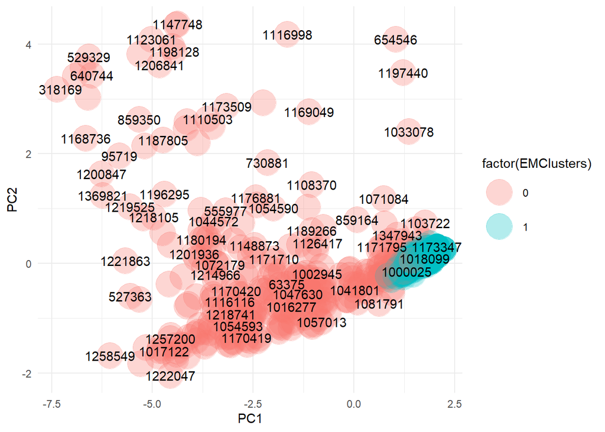

```r
ggplot(embedding, aes(x = PC1, y = PC2)) +
  geom_point(aes(colour = factor(EMClusters)), size = 10, alpha = 0.3) +
  geom_text(aes(label = Patient_ID), check_overlap = TRUE) +
  theme_minimal()
```

We find again that the benign cases are concentrated in a small region of space, while having outliers more dispersed.

However, we can think of considering more clusters and see what happens.

```r
expec.max2 <- Mclust(dataset.scaled, G = 6)
classifier2 <- expec.max2$classification #get the predictions
```

Let’s plot the predictions:

```r
embedding[, EMClusters2 := classifier2]
embedding
```

```
##             PC1         PC2 Patient_ID DClusters EMClusters EMClusters2
##   1:  1.3031545 -0.14855302    1000025         1          1           1
##   2: -0.9160961 -0.19060580    1002945         0          0           2
##   3:  1.5294509 -0.02905987    1015425         1          1           3
##   4: -1.5481522 -0.78457509    1016277         0          0           2
##   5:  1.1719109 -0.11651130    1017023         1          1           4
##  ---
## 695:  1.6657092  0.23978883     776715         1          1           4
## 696:  1.9411295  0.24746662     841769         1          1           6
## 697: -4.1077805 -0.74404564     888820         0          0           2
## 698: -2.3468848 -1.36372591     897471         0          0           2
## 699: -2.6648821 -1.38457326     897471         0          0           2
```

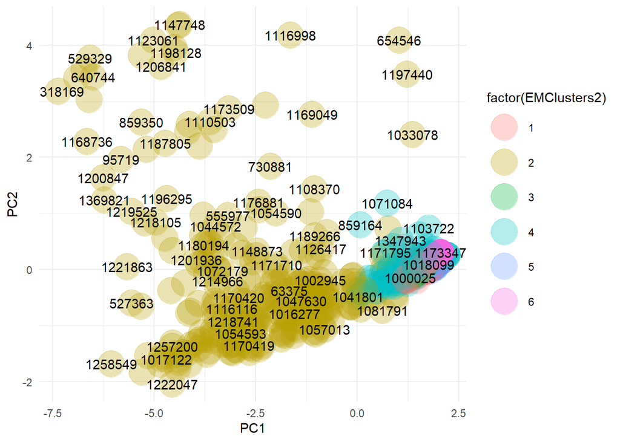

```r
ggplot(embedding, aes(x = PC1, y = PC2)) +
  geom_point(aes(colour = factor(EMClusters2)), size = 10, alpha = 0.3) +
  geom_text(aes(label = Patient_ID), check_overlap = TRUE) +
  theme_minimal()
```

Now, we find several clusters and, comparing with the known distribution of benign and malignant cases, we can associate cluster 2 to the malignant cases and the other ones to slight variations in the distribution for benign cases. Let’s go ahead with this assumption and see what we get:

```r
classifier2[classifier2==2]=0 #set the right label for negative predictions (malignant)
classifier2[classifier2!=0]=1 #set the right label for positive predictions (benign)
confusionMatrix(factor(classifier2), factor(class))
```

```
## Confusion Matrix and Statistics
##
##           Reference
## Prediction   0   1
##          0 234  28
##          1   7 430
##
##                Accuracy : 0.9499
##                  95% CI : (0.931, 0.9649)
##     No Information Rate : 0.6552
##     P-Value [Acc > NIR] : < 2.2e-16
##
##                   Kappa : 0.8914
##
##  Mcnemar's Test P-Value : 0.0007232
##
##             Sensitivity : 0.9710
##             Specificity : 0.9389
##          Pos Pred Value : 0.8931
##          Neg Pred Value : 0.9840
##              Prevalence : 0.3448
##          Detection Rate : 0.3348
##    Detection Prevalence : 0.3748
##       Balanced Accuracy : 0.9549
##
##        'Positive' Class : 0
##
```

With this assumption we are achieving both a higher accuracy and specificity while losing a bit of sensitivity. This approach has been a little bit tricky and is misclassifying more malignant cases and thus I would rather prefer the previous method with only 2 clusters.

### c) Local Outler Factor (LOF)

This algorithm compares the local density of a point with that of its neighbors. In the case that the former is notably lower than the latter, the point is in a sparser region than its neighbors, which makes it an outlier candidate.

```r
library(DMwR)
```

Particularly, the LOF algorithm compares the density of each point to the density of its k-closest neighbors. Thus, we need to specify the number of neighbors, k, used to determine the local outlier factors. It is really important to notice that, if we have more than k duplicate points in the data we are going to obtain Nan values caused by an infinite local density. According to the original paper, “LOF: Identifying Density-Based Local Outliers” (Breunig et al), it is recommended to choose a minimum k and a maximum k, and for each point, take the maximum LOF value over each k in that range. This is because the LOF values fluctuate wildly for low k values. A useful interpretation is that k represents something similar to the size of the desired cluster, and consequently we will take k=400.

```r
dataset[,] <- lapply(dataset[,], as.numeric) #first convert int variables to numeric to be able to make the following calculations
outlier.scores <- lofactor(dataset, k=400)
```

We can see now the probability density distribution of the LOF values:

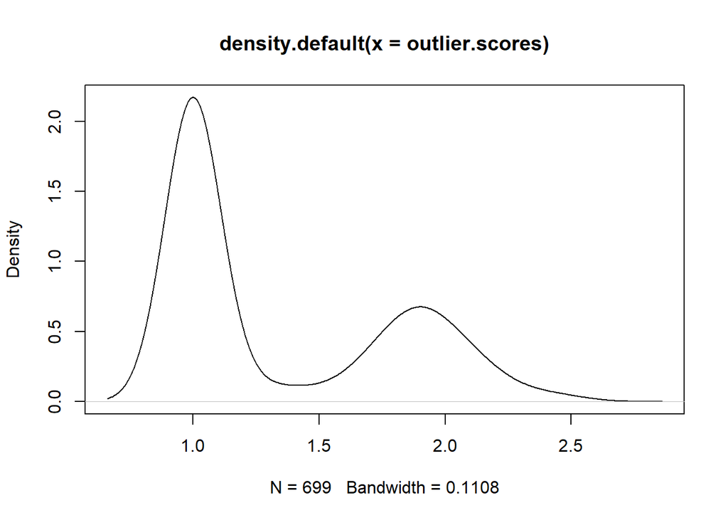

```r
plot(density(outlier.scores))
```

It is possible two observe two different distributions, which may mean that malignant and benign data come from two different mechanisms. We now identify who are the outliers and represent them:

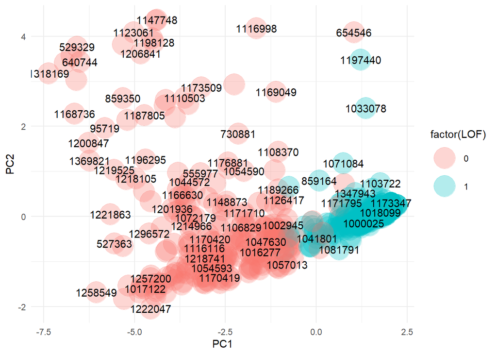

```r
outliers <- order(outlier.scores, decreasing = T)[1:241]#we choose as outliers the 241 points with the largest LOF and expect that they correspond to the 241 malignant cases, assuming the rest of the points to be benign predictions

n <- nrow(dataset)
labels <- 1:n
labels[-outliers] <- 1
labels[outliers] <- 0
embedding[, LOF := labels]

ggplot(embedding, aes(x = PC1, y = PC2)) +
  geom_point(aes(colour = factor(LOF)), size = 10, alpha = 0.3) +
  geom_text(aes(label = Patient_ID), check_overlap = TRUE) +
  theme_minimal()
```

Visually we find that the algorithm is identifying correctly the malignant and benign observations. Also notice that it is not presenting such density dependence as the previous methods. Finally, let’s compute the confussion matrix:

```r
confusionMatrix(factor(labels), factor(class))
```

```
## Confusion Matrix and Statistics
##
##           Reference
## Prediction   0   1
##          0 225  16
##          1  16 442
##
##                Accuracy : 0.9542
##                  95% CI : (0.936, 0.9685)
##     No Information Rate : 0.6552
##     P-Value [Acc > NIR] : <2e-16
##
##                   Kappa : 0.8987
##
##  Mcnemar's Test P-Value : 1
##
##             Sensitivity : 0.9336
##             Specificity : 0.9651
##          Pos Pred Value : 0.9336
##          Neg Pred Value : 0.9651
##              Prevalence : 0.3448
##          Detection Rate : 0.3219
##    Detection Prevalence : 0.3448
##       Balanced Accuracy : 0.9493
##
##        'Positive' Class : 0
##
```

What we find is that the LOF algorithm is performing in a similar way to the previous methods, showing large values for the accuracy, specificity and sensitivity, but presenting a lower dependence on density variations.

### Conclusion

Depending on which method we choose, the observations misclassified as outliers change. Thus, our results are highly dependent on the method chosen. Having said that, I would lean towards the method of expectation maximization (EM) as it is the one presenting the largest sensitivity while keeping a reasonable large value for the specificity.